# Flight metrics - Little Bustard (Tetrax tetrax)

Tiago Crispim-Mendes

2026-09-15

# Load packages

```r
library(tidyverse)
library(lubridate)
library(sf)
library(sp)
library(amt)
library(momentuHMM)
library(lookup)
library(raster)
library(DT)
library(htmltools)
library(future)
library(furrr)
library(purrr)

# Compute great-circle distance between successive locations in kilometres
haversine_distance <- function(lat1, lon1, lat2, lon2) {
  r <- 6371  # Earth's radius in km
  p <- pi / 180
  a <- 0.5 - cos((lat2 - lat1) * p) / 2 +
    cos(lat1 * p) * cos(lat2 * p) *
    (1 - cos((lon2 - lon1) * p)) / 2
  return(2 * r * asin(sqrt(a)))  # result in km
}
```

# Paths

Define input and output directories used throughout the workflow

```r
project_data_dir <- "Data"
project_results_dir <- "Results"

species_dir <- file.path("Little_Bustard")
raw_data_dir <- file.path(project_data_dir, species_dir, "Raw")
derived_data_dir <- file.path(project_data_dir, species_dir, "Data_paper")
results_dir <- file.path(project_results_dir, species_dir, "Data_paper")

# Create output directories if they do not exist
dir.create(derived_data_dir, recursive = TRUE, showWarnings = FALSE)
dir.create(results_dir, recursive = TRUE, showWarnings = FALSE)
```

# Load individual information

Load metadata used to match device identifiers to individuals and retrieve deployment, sex, age, and device information

```r
individual_info <- read.csv(
  file.path(
    raw_data_dir,
    "Individuals_data",
    "Info_individuals_LB.csv"
  ),
  sep = ";",
  na.strings = c("", "NA"),
  stringsAsFactors = FALSE
)
```

# Data preparation

Prepare per-individual tracking datasets, identify acquisition modes, derive phenological phase and daytime period, extract terrain elevation, and create the 30-min resampled sequences used in later analyses

```r
# List all raw tracking files
files <- list.files(path = raw_data_dir,pattern = "0\\.csv$")

# Define speed thresholds used to identify flight records and valid boost flights
flight_speed_threshold_km_h<-7
displacement_speed_threshold_km_h<- 3

# Load the UTM grid used to match each location to the appropriate DEM tile
utm_grid <- st_read(
  "MDT/MTN25_ACTUAL_ETRS89_Peninsula_Baleares_Canarias.shp",
  quiet = TRUE
)
utm_grid <- st_transform(utm_grid, CRS("+init=epsg:25830"))

# Store one summary row per individual
individual_summary<-NULL

for(i in files) {
  tryCatch({

    # Keep GPS records only and preserve chronological order
    x <- read.csv(file.path(raw_data_dir, i), sep = ",") %>%
      dplyr::filter(datatype == "GPS")

    x$UTC_datetime <- as.POSIXct(
      x$UTC_datetime,
      format = "%Y-%m-%d %H:%M:%OS",
      tz = "GMT"
    )

    x <- x %>%dplyr::arrange(UTC_datetime)

    # Remove pre-existing coordinate fields that will be recalculated below
    x <- x %>% dplyr::select(-dplyr::any_of("X"))

    # Match each file to a single tracked individual
    individual <-lookup(unique(na.omit(x$device_id)),individual_info$IDnum,individual_info$ID_new)
    x$Individual_ID <- individual

    burst_size <- as.numeric(
      lookup(individual, individual_info$ID_new, individual_info$Brust_size)
    )

    # Shift exact midnight timestamps slightly to avoid ordering problems
    x <- x %>%
      mutate(
        UTC_datetime = if_else(
          format(UTC_datetime, "%H:%M:%S") == "00:00:00",
          UTC_datetime + seconds(1),
          UTC_datetime
        )
      )

    # Harmonise altitude field names across files
    if ("MSL_altitude_m" %in% names(x)) {
      x <- x %>%
        dplyr::rename(Altitude_m = MSL_altitude_m)
      }

    # Harmonise speed field names across files
    if ("speed_km.h" %in% names(x)) {
      x <- x %>%
        dplyr::rename(speed_km_h = `speed_km.h`)
      }

    # Exclude the first week after deployment and all records after the last transmission
    deploy<-lookup(individual,individual_info$ID_new,individual_info$capture_date)
    death<-lookup(individual,individual_info$ID_new,individual_info$last_location)

    x<-x[x$UTC_date>as.Date(deploy) + 7,]
    x<-x[x$UTC_date<as.Date(death),]

    # Create a stable row identifier for joins throughout the workflow
    x$IDorder <- seq_len(nrow(x))

    # Append device metadata to each record
    x$gps_brand<-lookup(individual,individual_info$ID_new,individual_info$GPS_Brand)
    x$gps_model<-lookup(individual,individual_info$ID_new,individual_info$GPS_Model)
    x$gps_model_full<-lookup(individual,individual_info$ID_new,individual_info$GPS_Model_full)

    # Derive coordinates in geographic and projected reference systems
    x_sf <- st_as_sf(x, coords = c("Longitude", "Latitude"), crs = 4326)

    x <- x_sf %>%
      mutate(
        X = st_coordinates(.)[, 1],
        Y = st_coordinates(.)[, 2],
        X_25829 = st_coordinates(st_transform(geometry, crs = 25829))[, 1],
        Y_25829 = st_coordinates(st_transform(geometry, crs = 25829))[, 2],
        X_25830 = st_coordinates(st_transform(geometry, crs = 25830))[, 1],
        Y_25830 = st_coordinates(st_transform(geometry, crs = 25830))[, 2]
      ) %>%
      st_drop_geometry()

    # Assign each record to the focal phenological phases used in the analyses
    classify_phenology <- function(x) {
      x <- x %>%
        mutate(
          phen_phase = case_when(
            (month(UTC_datetime) == 4 & day(UTC_datetime) >= 1) |
              (month(UTC_datetime) == 5 & day(UTC_datetime) <= 15) ~ "breeding",
            (month(UTC_datetime) == 7 & day(UTC_datetime) >= 15) |
              (month(UTC_datetime) == 8) |
              (month(UTC_datetime) == 9 & day(UTC_datetime) <= 15) ~ "post_breeding",
            (month(UTC_datetime) == 12 & day(UTC_datetime) >= 15) |
              (month(UTC_datetime) == 1) |
              (month(UTC_datetime) == 2 & day(UTC_datetime) <= 15) ~ "winter",
            TRUE ~ "other"
          )
        )
      return(x)
    }

    x <- classify_phenology(x)

        # Calculate sunrise and sunset for each GPS fix
    sun_input <- x %>%
      transmute(
        IDorder,
        date = as.Date(UTC_date),
        lat = Y,
        lon = X
      )

    sun_times <- suncalc::getSunlightTimes(
      data = sun_input %>%
        dplyr::select(date, lat, lon),
      keep = c("sunrise", "sunset"),
      tz = "UTC"
    ) %>%
      mutate(
        IDorder = sun_input$IDorder
      ) %>%
      dplyr::select(
        IDorder,
        sunrise,
        sunset
      )

    # Classify each GPS fix by daytime period using custom dawn/dusk windows
    # Dawn and dusk are defined as 2-hour windows centred on sunrise and sunset, respectively
    x <- x %>%
      left_join(sun_times, by = "IDorder") %>%
      mutate(
        tod = case_when(
          UTC_datetime >= sunrise - hours(1) &
            UTC_datetime <= sunrise + hours(1) ~ "dawn",

          UTC_datetime >= sunset - hours(1) &
            UTC_datetime <= sunset + hours(1) ~ "dusk",

          UTC_datetime > sunrise + hours(1) &
            UTC_datetime < sunset - hours(1) ~ "day",

          TRUE ~ "night"
        ),

        tod = factor(
          tod,
          levels = c("dawn", "day", "dusk", "night")
        )
      ) %>%
      dplyr::select(
        -sunrise,
        -sunset
      )

    # Compute elapsed time between consecutive records
    x$lag_original <- c(NA, diff(x$UTC_datetime, units = "secs"))

    # Identify short-interval sequences corresponding to burst and boost acquisitions
    x$burst<-ifelse(x$lag_original<11, 1,0)

    x$burst2<-NA
    x$acquisition_mode<-NA
    x<-x[!is.na(x$UTC_datetime),]
    rownames(x) <- 1:nrow(x)

    y<-rle(x$burst == 1)
    y$sumcum<-cumsum(y$lengths)

    for(j in 2:length(y$sumcum)) {

      if(y$values[j]=="TRUE"){

        ya<-y$sumcum[j-1]
        yb<-y$sumcum[j]

        x$burst2[ya:yb]<-y$lengths[j]+1
        x$acquisition_mode[ya:yb]<-"burst_boost"
        x$acquisition_mode[yb] <- ifelse(x$burst2[yb] > burst_size, "boost_end", "burst_end")
```

```r
      }else{

        if(y$lengths[j]==1){
        }else{

          ya<-y$sumcum[j-1]+1
          yb<-y$sumcum[j]-1

          x$burst2[ya:yb]<-y$lengths[j]-1
          x$acquisition_mode[ya:yb]<-"simple"

        }

      }}

    # Reduce acquisition labels to the categories used in downstream analyses
    x$acquisition_mode2<-ifelse(c(x$acquisition_mode=="burst_boost"&x$burst2>burst_size),"boost","burst")
    x$acquisition_mode2<-ifelse(c(x$acquisition_mode=="burst_boost"&x$burst==0&x$burst2>burst_size),"boost_start",x$acquisition_mode2)
    x$acquisition_mode2<-ifelse(c(x$acquisition_mode=="simple"),"simple",x$acquisition_mode2)
    x$acquisition_mode2<-ifelse(c(x$acquisition_mode=="burst_end"),"burst_end",x$acquisition_mode2)
    x$acquisition_mode2<-ifelse(c(x$acquisition_mode=="boost_end"),"boost_end",x$acquisition_mode2)

    x$acquisition_mode<-x$acquisition_mode2
    x$acquisition_mode2<-NULL

    # Use speed to separate clearly stationary records from likely flight records
    x <- x %>%
    mutate(behavior = case_when(
      speed_km_h == 0 ~ "stationary",
      speed_km_h > flight_speed_threshold_km_h  ~ "flight",
      TRUE ~ NA_character_
    ))

    # Flag low-quality points and implausible displacements before further processing
    x$filter<-ifelse(c(x$acquisition_mode=="burst"|x$X==0|x$Y==0|x$satcount<4),"REMOVE","OK")

    data <- x %>%
      filter(acquisition_mode %in% c("simple", "burst_end", "boost_start")&
      filter == "OK")

    data <- data %>%
      mutate(
        distancefromKM = haversine_distance(lag(Y), lag(X), Y, X)
        )

    data$difftimefrom <- c(NA, diff(data$UTC_datetime, units = "secs"))
    data$difftimefromHR<-data$difftimefrom/3600

    data$KMH<-as.numeric(data$distancefromKM/data$difftimefromHR)
    data$outlier<-ifelse(data$KMH>150, "yes","no")

    x$outlier<-lookup(x$IDorder,data$IDorder,data$outlier)

    x$filter<-ifelse(c(x$outlier=="yes"|x$acquisition_mode=="burst"|x$X==0|x$Y==0|x$satcount<4),"REMOVE","OK")

    # Extract ground elevation from the appropriate DEM tile and derive altitude above ground
    altitude_input_data <- x %>%
      dplyr::filter(is.na(filter) | filter == "OK")

    altitude_input_data$X_25830_original <- altitude_input_data$X_25830
    altitude_input_data$Y_25830_original <- altitude_input_data$Y_25830

    altitude_points_sf <- st_as_sf(
      x = altitude_input_data,
      coords = c("X_25830", "Y_25830"),
      crs = CRS("+init=epsg:25830")
    )

    altitude_points_intersection <- st_intersection(utm_grid, altitude_points_sf)

    altitude_points_intersection <- altitude_points_intersection[
      , !(names(altitude_points_intersection) %in% c("gid", "huso2", "solape", "edicion"))
    ]

    altitude_points_intersection$X_25830 <- altitude_points_intersection$X_25830_original
    altitude_points_intersection$Y_25830 <- altitude_points_intersection$Y_25830_original

    # Store terrain extraction results across DEM tiles
    altitude_results_list <- list()

    for (j in unique(na.omit(altitude_points_intersection$numero))) {
      tryCatch({
        altitude_points_zone <- altitude_points_intersection[altitude_points_intersection$numero == j, ]
        altitude_points_zone <- data.frame(altitude_points_zone)
        altitude_points_zone <- altitude_points_zone[!is.na(altitude_points_zone$X_25830), ]
        altitude_points_zone <- altitude_points_zone[, !(names(altitude_points_zone) %in% c("geometry"))]

        coordinates(altitude_points_zone) <- cbind(
          altitude_points_zone$X_25830,
          altitude_points_zone$Y_25830
        )
        crs(altitude_points_zone) <- CRS("+init=epsg:25830")

        mdt_file <- NULL

        # Extract terrain elevation using the appropriate UTM zone
        altitude_points_zone$ground_elevation <- ifelse(
          altitude_points_zone$huso == 30,
          {
            mdt_file <- paste0(
              "MDT/MDT02-ETRS89-HU",
              unique(na.omit(altitude_points_zone$huso)),
              "-",
              j,
              "-COB2.tif"
            )
            mdt <- raster(mdt_file)
            crs(mdt) <- CRS("+init=epsg:25830")
            raster::extract(mdt, altitude_points_zone)
          },
          ifelse(
            altitude_points_zone$huso == 29,
            {
              altitude_points_zone <- spTransform(
                altitude_points_zone,
                CRS("+init=epsg:25829")
              )

              mdt_file <- paste0(
                "MDT/MDT02-ETRS89-HU",
                unique(na.omit(altitude_points_zone$huso)),
                "-",
                j,
                "-COB2.tif"
              )
              mdt <- raster(mdt_file)
              crs(mdt) <- CRS("+init=epsg:25829")
              raster::extract(mdt, altitude_points_zone)
            },
            NA
          )
        )

        altitude_points_zone <- as.data.frame(altitude_points_zone)
        altitude_points_zone <- altitude_points_zone[
          , !(names(altitude_points_zone) %in% c("coords.x1", "coords.x2"))
        ]

        altitude_points_zone$altitude_above_ground <-
          altitude_points_zone$Altitude_m - altitude_points_zone$ground_elevation

        altitude_results_list[[length(altitude_results_list) + 1]] <- altitude_points_zone

      }, error = function(e) {
        cat(
          "ERROR:",
          individual,
          conditionMessage(e),
          if (!is.null(mdt_file)) mdt_file else "",
          "\n"
        )
      })
    }

    altitude_results <- dplyr::bind_rows(altitude_results_list) %>%
      dplyr::select(dplyr::any_of(c("IDorder", "huso", "ground_elevation", "altitude_above_ground")))

    # Merge terrain-based altitude estimates back into the full dataset
    if (nrow(altitude_results) == 0) {
      x$huso <- NA
      x$ground_elevation <- NA
      x$altitude_above_ground <- NA
    } else {
      x <- x %>%
        left_join(altitude_results, by = "IDorder")
    }

    # Assign UTM zone 29 to unmatched records after DEM extraction
    if (any(is.na(x$huso))) {
      x$huso[is.na(x$huso)] <- 29
    }
```

```r
    # Assign a boost identifier to each boost sequence
    x$boostID<-NA
    id<-1
    for(k in 2:nrow(x)){
      tryCatch({
        if(!is.na(x$acquisition_mode[k]) && x$acquisition_mode[k] == "boost_start") {
          x2<-x[k:nrow(x),]
          x$boostID[k:rownames(x2[x2$acquisition_mode=="boost_end",])[1]]<-paste("boost_",id,sep="")
          id<-id+1
          }  }, error=function(e){cat("ERROR :",conditionMessage(e), "\n")})
    }

    # Identify boost sequences that likely correspond to flight events
    x$KMH_boost <- NA
    x$boost_flight_ID <- NA
    flight_id <- 1

    for (k in 2:nrow(x)) {
      tryCatch({
        if (!is.na(x$acquisition_mode[k]) && x$acquisition_mode[k] == "boost_start") {

          x2 <- x[k:nrow(x),]
          boost_end_idx <- rownames(x2[x2$acquisition_mode == "boost_end", ])[1]

          if (!is.na(boost_end_idx)) {
            boost_range <- k:as.integer(boost_end_idx)

            speed_condition <- any(x$speed_km_h[boost_range] > flight_speed_threshold_km_h, na.rm = TRUE)

            start_point <- x[k, ]
            end_point <- x[as.integer(boost_end_idx), ]

            distance_boost <- haversine_distance(start_point$Y, start_point$X, end_point$Y, end_point$X)

            time_boost_sec <- as.numeric(difftime(end_point$UTC_datetime, start_point$UTC_datetime, units = "secs"))

            KMH_boost <- ifelse(time_boost_sec > 0, (distance_boost / time_boost_sec) * 3600, 0)

            x$KMH_boost[boost_range] <- KMH_boost

            if (speed_condition && KMH_boost > displacement_speed_threshold_km_h) {
              x$boost_flight_ID[boost_range] <- paste("boostflight_", flight_id, sep = "")
              flight_id <- flight_id + 1
            }
          }
        }
      }, error = function(e) { cat("ERROR :", conditionMessage(e), "\n") })
    }

    # Resample valid records to a standard 30-min interval within each phenological phase
    x_split <- x %>%
      filter(!is.na(filter) & filter == "OK") %>%
      group_split(phen_phase)

    x_processed <- lapply(x_split, function(df) {

      x_track_data <- make_track(
        df, .x = X, .y = Y, .t = UTC_datetime,
        crs = 4326, IDorder = IDorder
      )

      x_resampled_track <- x_track_data |>
        track_resample(rate = minutes(30), tolerance = minutes(2)) |>
        filter_min_n_burst(min_n = 3)

      df <- df %>%
        left_join(
          dplyr::select(x_resampled_track, IDorder, ID_keep = burst_),
          by = "IDorder"
        )

      # Store each retained 30-min sequence as an individual- and phase-specific identifier
      df$ID_keep <- ifelse(
        !is.na(df$ID_keep),
        paste0(df$Individual_ID, "_",df$phen_phase, "_", df$ID_keep),
        df$ID_keep
      )
      df$ID_keep <- as.character(df$ID_keep)

      return(df)
    })

    all_processed <- bind_rows(x_processed)

    x <- x %>%
      left_join(
        dplyr::select(all_processed, IDorder, ID_keep),
        by = "IDorder"
      )

    # Summarise tracking coverage and the amount of data retained at each step
    individual_summary_temp <- tibble(
      individual_id = unique(x$Individual_ID),
      sex = lookup(unique(na.omit(x$device_id)), individual_info$IDnum, individual_info$Sex),
      age = lookup(unique(na.omit(x$device_id)), individual_info$IDnum, individual_info$Age),
      gps_brand = unique(x$gps_brand),
      gps_model = unique(x$gps_model),
      gps_model_full = unique(x$gps_model_full),
      tracking_start = min(x$UTC_date, na.rm = TRUE),
      tracking_end = max(x$UTC_date, na.rm = TRUE),
      tracking_duration_days = round(as.numeric(difftime(max(x$UTC_datetime, na.rm = TRUE), min(x$UTC_datetime, na.rm = TRUE), units = "days"))),
      n_fixes_raw = nrow(x),
      n_fixes_30min = sum(!is.na(x$ID_keep)),
      n_fixes_stationary = sum(x$behavior == "stationary", na.rm = TRUE),
      n_fixes_flight = sum(x$behavior == "flight", na.rm = TRUE)
    )

    phases <- c("breeding", "post_breeding", "winter", "other")

    # Add phase-specific counts for the main acquisition and behavioural categories
    for (phase in phases) {
      x_phase <- x[x$phen_phase == phase & !is.na(x$phen_phase), ]
      individual_summary_temp[[paste0("n_fixes_simple_", phase)]] <- sum(x_phase$acquisition_mode == "simple", na.rm = TRUE)
      individual_summary_temp[[paste0("n_burst_events_", phase)]] <- sum(x_phase$acquisition_mode == "burst_end", na.rm = TRUE)
      individual_summary_temp[[paste0("n_boost_events_", phase)]] <- sum(x_phase$acquisition_mode == "boost_end", na.rm = TRUE)
      individual_summary_temp[[paste0("n_boost_flight_events_", phase)]] <- length(unique(na.omit(x_phase$boost_flight_ID)))
      individual_summary_temp[[paste0("n_fixes_30min_", phase)]] <- sum(!is.na(x_phase$ID_keep))
      individual_summary_temp[[paste0("n_sequences_30min_", phase)]] <- length(unique(na.omit(x_phase$ID_keep)))
      individual_summary_temp[[paste0("n_fixes_stationary_", phase)]] <- sum(x_phase$behavior == "stationary" &!is.na(x_phase$altitude_above_ground), na.rm = TRUE)
      individual_summary_temp[[paste0("n_fixes_flight_", phase)]] <- sum(x_phase$behavior == "flight"&!is.na(x_phase$altitude_above_ground), na.rm = TRUE)
    }

    individual_summary<-rbind(individual_summary,individual_summary_temp)

    # Save the prepared per-individual dataset used in downstream analyses
    write.csv(x,file.path(derived_data_dir, paste0(individual, "_Data_Prep.csv")),row.names = FALSE)

}, error=function(e){cat("ERROR:",individual,conditionMessage(e), "\n")})

}
```

```
## ERROR: LB_21 Cannot create a RasterLayer object from this file. (file does not exist) MDT/MDT02-ETRS89-HU30-0510-3-COB2.tif
```

```r
# Save the individual-level summary table
individual_summary <- individual_summary %>% arrange(individual_id)
write.csv(individual_summary, file.path(results_dir, "Individuals_data_summary.csv"), row.names = FALSE)

tagList(
  h3("Individual summary"),
  datatable(individual_summary, options = list(scrollX = TRUE, scrollY = TRUE, pageLength = 10))
)
```

### Individual summary

|  | individual_id | sex | age | gps_brand | gps_model | gps_model_full | tracking_start | tracking_end | tracking_duration_days | n_fixes_raw | n_fixes_30min | n_fixes_stationary | n_fixes_flight | n_fixes_simple_breeding | n_burst_events_breeding | n_boost_events_breeding | n_boost_flight_events_breeding | n_fixes_30min_breeding | n_sequences_30min_breeding | n_fixes_stationary_breeding | n_fixes_flight_breeding | n_fixes_simple_post_breeding | n_burst_events_post_breeding | n_boost_events_post_breeding | n_boost_flight_events_post_breeding | n_fixes_30min_post_breeding | n_sequences_30min_post_breeding | n_fixes_stationary_post_breeding | n_fixes_flight_post_breeding | … |
| --- | --- | --- | --- | --- | --- | --- | --- | --- | --- | --- | --- | --- | --- | --- | --- | --- | --- | --- | --- | --- | --- | --- | --- | --- | --- | --- | --- | --- | --- | --- |
| 1 | LB_01 | Male | Adult | Ornitela | OT-25 | OT-25-2GC | 2021-05-21 | 2022-09-16 | 484 | 613246 | 12896 | 534651 | 3537 | 156 | 8375 | 0 | 0 | 1381 | 127 | 7943 | 25 | 2369 | 13545 | 0 | 0 | 3497 | 372 | 13898 | 37 | … |
| 2 | LB_02 | Male | Adult | Ornitela | OT-25 | OT-25-2GC | 2021-04-29 | 2025-04-21 | 1454 | 767113 | 35103 | 618408 | 7473 | 1284 | 15333 | 22 | 16 | 5156 | 186 | 14151 | 384 | 4159 | 17435 | 6 | 2 | 6946 | 269 | 17740 | 257 | … |
| 3 | LB_03 | Male | Adult | Ornitela | OT-20 | OT-20-2GC-C36 | 2021-05-06 | 2022-02-21 | 292 | 123539 | 7852 | 92896 | 1303 | 144 | 995 | 0 | 0 | 447 | 30 | 858 | 19 | 0 | 0 | 0 | 0 | 0 | 0 | 0 | 0 | … |
| 4 | LB_04 | Male | Adult | Ornitela | OT-20 | OT-20-2GC-C36 | 2021-05-07 | 2022-04-17 | 346 | 229052 | 13684 | 161829 | 1821 | 493 | 2415 | 0 | 0 | 1106 | 106 | 2113 | 24 | 3257 | 2466 | 0 | 0 | 1992 | 176 | 3682 | 17 | … |
| 5 | LB_05 | Male | Adult | Ornitela | OT-25 | OT-25-2GC | 2021-05-12 | 2021-08-02 | 83 | 76870 | 2579 | 64057 | 356 | 11 | 382 | 1 | 0 | 127 | 4 | 355 | 0 | 86 | 1732 | 0 | 0 | 577 | 22 | 1632 | 7 | … |
| 6 | LB_06 | Male | Adult | Ornitela | OT-25 | OT-25-2GC | 2021-05-12 | 2024-12-30 | 1329 | 615609 | 28199 | 509716 | 3017 | 1009 | 12408 | 1 | 0 | 4136 | 154 | 11678 | 50 | 5921 | 15644 | 0 | 0 | 6343 | 271 | 18252 | 93 | … |
| 7 | LB_07 | Male | Adult | Ornitela | OT-15 | OT-15-2GC-C36 | 2022-04-12 | 2024-08-07 | 849 | 292826 | 20831 | 234743 | 2864 | 1416 | 10223 | 0 | 0 | 3679 | 136 | 9880 | 88 | 3254 | 8203 | 0 | 0 | 3890 | 171 | 9591 | 60 | … |
| 8 | LB_08 | Male | Adult | Ornitela | OT-15 | OT-15-2GC-C36 | 2022-05-04 | 2023-08-10 | 464 | 215520 | 12920 | 186840 | 1152 | 478 | 5261 | 0 | 0 | 1779 | 57 | 5056 | 25 | 1151 | 7438 | 3 | 0 | 2697 | 101 | 7734 | 44 | … |
| 9 | LB_09 | Male | Adult | Ornitela | OT-15 | OT-15-2GC-C36 | 2022-05-04 | 2024-04-13 | 711 | 301251 | 17949 | 217940 | 2777 | 594 | 6395 | 0 | 0 | 2126 | 132 | 5293 | 42 | 2554 | 8322 | 0 | 0 | 3281 | 309 | 8042 | 63 | … |
| 10 | LB_10 | Male | Adult | Ornitela | OT-15 | OT-15-2GC-C36 | 2022-05-15 | 2025-03-23 | 1044 | 309956 | 22968 | 252299 | 3131 | 767 | 8496 | 0 | 0 | 2835 | 92 | 8084 | 68 | 5879 | 7688 | 0 | 0 | 4562 | 221 | 11429 | 69 | … |

[output cut: 27 more lines]

# Boosts

## Correction factor for flight distances

Summarise high-frequency boost flights to estimate the ratio between cumulative path length and straight-line displacement

```r
# List prepared per-individual datasets
files <- list.files(path = derived_data_dir, pattern = "Data_Prep\\.csv$")

# Store boost records and per-flight summaries across all individuals
boost_flight_data_list <- list()
boost_distance_summary_list <- list()

for (i in files) {
  tryCatch({
    # Read one prepared dataset and preserve chronological order
    df_complete <- read.csv(file.path(derived_data_dir, i), sep = ",") %>%
      dplyr::mutate(
        device_id = as.character(device_id),
        Individual_ID = as.character(Individual_ID),
        boost_flight_ID = as.character(boost_flight_ID),
        boostID = as.character(boostID),
        phen_phase = as.character(phen_phase),
        acquisition_mode = as.character(acquisition_mode),
        behavior = as.character(behavior),
        filter = as.character(filter)
      )

    # Match the file to a single individual
    individual <- lookup(
      unique(na.omit(df_complete$device_id)),
      individual_info$IDnum,
      individual_info$ID_new
    )

    df_complete$UTC_datetime <- as.POSIXct(
      df_complete$UTC_datetime,
      format = "%Y-%m-%d %H:%M:%OS",
      tz = "GMT"
    )

    df_complete <- df_complete[order(df_complete$UTC_datetime), ]

    # Keep only boost sequences previously classified as flight
    df_filtered <- df_complete[!is.na(df_complete$boost_flight_ID), ]

    if (nrow(df_filtered) > 0) {
      boost_flight_data_list[[length(boost_flight_data_list) + 1]] <- df_filtered
    }

    # Summarise each boost flight independently
    for (boost_id in unique(df_filtered$boost_flight_ID)) {

      df_boost <- df_filtered[df_filtered$boost_flight_ID == boost_id, ]
      df_boost <- df_boost[order(df_boost$UTC_datetime), ]

      # Skip incomplete boost flights with fewer than two records
      if (nrow(df_boost) < 2) next

      phen_phase <- unique(df_boost$phen_phase)[1]

      # Sum successive step lengths within the boost sequence
      df_boost$distancefromKM <- haversine_distance(
        lag(df_boost$Y),
        lag(df_boost$X),
        df_boost$Y,
        df_boost$X
      )

      total_distance <- sum(df_boost$distancefromKM, na.rm = TRUE)

      # Compare cumulative distance with straight-line displacement
      first_point <- df_boost[1, ]
      last_point <- df_boost[nrow(df_boost), ]

      displacement <- haversine_distance(
        first_point$Y,
        first_point$X,
        last_point$Y,
        last_point$X
      )

      correction_factor <- ifelse(displacement > 0, total_distance / displacement, NA_real_)

      result <- data.frame(
        Individual_ID = individual,
        boost_flight_ID = boost_id,
        first_datetime = first_point$UTC_datetime,
        last_datetime = last_point$UTC_datetime,
        phen_phase = phen_phase,
        total_distance_Km = total_distance,
        displacement_Km = displacement,
        correction_factor = correction_factor
      )

      boost_distance_summary_list[[length(boost_distance_summary_list) + 1]] <- result
    }

  }, error = function(e) {
    cat("ERROR in file:", i, "-", conditionMessage(e), "\n")
  })
}

# Combine all boost-level outputs
boost_flight_data <- dplyr::bind_rows(boost_flight_data_list)
boost_distance_summary <- dplyr::bind_rows(boost_distance_summary_list)

# Summarise correction factors by phenological phase
summary_table_correction_factor <- boost_distance_summary %>%
  group_by(phen_phase) %>%
  summarise(
    mean_correction_factor = mean(correction_factor, na.rm = TRUE),
    sd_correction_factor = sd(correction_factor, na.rm = TRUE),
    median_correction_factor = median(correction_factor, na.rm = TRUE)
  )

# Add a global summary across all phases
total_summary_correction_factor <- boost_distance_summary %>%
  summarise(
    phen_phase = "Global",
    mean_correction_factor = mean(correction_factor, na.rm = TRUE),
    sd_correction_factor = sd(correction_factor, na.rm = TRUE),
    median_correction_factor = median(correction_factor, na.rm = TRUE)
  )

summary_correction_factor <- bind_rows(summary_table_correction_factor, total_summary_correction_factor)

tagList(
  h3("Correction factor"),
  datatable(summary_correction_factor, options = list(scrollX = TRUE, scrollY = TRUE, pageLength = 5))
)
```

### Correction factor

|  | phen_phase | mean_correction_factor | sd_correction_factor | median_correction_factor |
| --- | --- | --- | --- | --- |
| 1 | breeding | 1.947097008876828 | 1.668973242232883 | 1.339209171807274 |
| 2 | other | 1.976611081692619 | 1.843871313695655 | 1.332862405682543 |
| 3 | post_breeding | 1.567010163034919 | 1.407038106205067 | 1.193098351043411 |
| 4 | winter | 2.900360615446885 | 2.508310028501699 | 1.999614242909682 |
| 5 | Global | 1.97116882235617 | 1.798120052523002 | 1.330966080287311 |

## Boost displacement 30 min

Match each boost start to the nearest valid location approximately 30 min later to derive the flight displacement used to inform HMM initial values

```r
# List prepared per-individual datasets
files <- list.files(path = derived_data_dir,pattern = "Data_Prep\\.csv$")

# Store one summary row per matched boost pair
boost_displacement_summary <- NULL

for (file_name in files) {
  tryCatch({
    # Read one prepared dataset and preserve chronological order
    df_complete <- read.csv(
      file.path(derived_data_dir, file_name),
      sep = ","
    )

    individual <- lookup(
      unique(na.omit(df_complete$device_id)),
      individual_info$IDnum,
      individual_info$ID_new
    )

    df_complete$UTC_datetime <- as.POSIXct(
      df_complete$UTC_datetime,
      format = "%Y-%m-%d %H:%M:%OS",
      tz = "GMT"
    )

    df_complete <- df_complete[order(df_complete$UTC_datetime), ]

    # Use only valid records when matching the 30-min endpoint
    df_filtered <- df_complete[!is.na(df_complete$filter) & df_complete$filter == "OK", ]

    # Keep boost starts associated with boost flights
    df_boost <- df_filtered %>%
      dplyr::filter(acquisition_mode == "boost_start", !is.na(boost_flight_ID))

    if (nrow(df_boost) > 0) {

      # Store matched start-end pairs
      df_boost_pairs <- data.frame()
      counter <- 1

      for (j in 1:nrow(df_boost)) {
        start_point <- df_boost[j, ]
        target_time <- start_point$UTC_datetime + 1800

        # Search for the nearest valid point after the boost start
        candidates <- df_filtered %>%
          dplyr::filter(UTC_datetime > start_point$UTC_datetime)

        if (nrow(candidates) > 0) {
          candidates$delta_abs <- abs(as.numeric(
            difftime(candidates$UTC_datetime, target_time, units = "secs")
          ))

          closest_candidate <- candidates[which.min(candidates$delta_abs), ]

          delta_real <- as.numeric(
            difftime(closest_candidate$UTC_datetime, start_point$UTC_datetime, units = "secs")
          )

          # Retain matches within a ±3 min tolerance around 30 min
          if (delta_real >= 1620 && delta_real <= 1980) {
            temp_rows <- dplyr::bind_rows(start_point, closest_candidate)
            temp_rows$ID_boost_to <- paste0(start_point$device_id, "_", counter)
            df_boost_pairs <- dplyr::bind_rows(df_boost_pairs, temp_rows)
            counter <- counter + 1
          }
        }
      }

      # Summarise each matched pair as a single 30-min displacement value
      if (nrow(df_boost_pairs) > 0) {

        df_boost_pairs <- df_boost_pairs %>%
          dplyr::arrange(ID_boost_to, UTC_datetime) %>%
          dplyr::group_by(ID_boost_to) %>%
          dplyr::mutate(
            displacement_30min = haversine_distance(dplyr::lag(Y), dplyr::lag(X), Y, X)
          ) %>%
          dplyr::summarise(
            Individual_ID = dplyr::first(Individual_ID),
            boost_flight_ID = dplyr::first(stats::na.omit(boost_flight_ID)),
            phen_phase = dplyr::first(phen_phase),
            displacement_30min = dplyr::first(stats::na.omit(displacement_30min)),
            .groups = "drop"
          )

        boost_displacement_summary <- dplyr::bind_rows(
          boost_displacement_summary,
          df_boost_pairs
        )
      }}
  }, error = function(e) {cat("ERROR:", file_name, "-", conditionMessage(e), "\n")})
  }

# Summarise 30-min displacement globally and by phenological phase
flight_displacement_calibration_global <- boost_displacement_summary %>%
  summarise(
    phen_phase = "Global",
    mean_displacement = mean(displacement_30min, na.rm = TRUE),
    sd_displacement = sd(displacement_30min, na.rm = TRUE),
    )

flight_displacement_calibration_by_phase <- boost_displacement_summary %>%
  group_by(phen_phase) %>%
  summarise(
    mean_displacement = mean(displacement_30min, na.rm = TRUE),
    sd_displacement = sd(displacement_30min, na.rm = TRUE),
    )

flight_displacement_summary <- bind_rows(flight_displacement_calibration_global, flight_displacement_calibration_by_phase)

tagList(
  h3("Flight displacement summary"),
  datatable(flight_displacement_summary, options = list(scrollX = TRUE, scrollY = TRUE, pageLength = 5))
)
```

### Flight displacement summary

|  | phen_phase | mean_displacement | sd_displacement |
| --- | --- | --- | --- |
| 1 | Global | 0.5439039801079607 | 0.9974174118294313 |
| 2 | breeding | 0.5034946455134987 | 0.8782957176398142 |
| 3 | other | 0.5760447469211049 | 1.051721183393691 |
| 4 | post_breeding | 0.5741394660191131 | 1.214705479642847 |
| 5 | winter | 0.4933749423154473 | 0.7867728027557761 |

## Boost flight data

Derive step lengths and turning angles for boost flights and export the boost-level movement dataset used for calibration

```r
boost_flight_data <- boost_flight_data %>%
  mutate(
    ID = paste0(Individual_ID, "_", boost_flight_ID),
    x = as.numeric(X),
    y = as.numeric(Y),
    time = as.POSIXct(UTC_datetime, tz = "UTC")
  ) %>%
  filter(!is.na(ID), !is.na(x), !is.na(y), !is.na(time)) %>%
  arrange(ID, time)

boost_flight_data_step_angle <- prepData(boost_flight_data, type = "LL")

# Export the boost-level dataset with step lengths and turning angles
boost_flight_data_filtered <- boost_flight_data_step_angle %>%
  dplyr::select(
    Individual_ID,
    boost_flight_ID,
    step,
    angle,
    UTC_datetime,
    phen_phase,
    tod,
    acquisition_mode,
    satcount,
    U_bat_mV,
    bat_soc_pct,
    solar_I_mA,
    hdop,
    Altitude_m,
    speed_km_h,
    direction_deg,
    #temperature_C,
    mag_x, mag_y, mag_z,
    acc_x, acc_y, acc_z,
    behavior,
    ground_elevation,
    altitude_above_ground
  )

write.csv(boost_flight_data_filtered,file.path(results_dir,"Boost_flight_data.csv"),row.names = FALSE)
```

## Boost summary

Combine within-boost path metrics with the matched 30-min displacement summary

```r
boost_flight_summary <- boost_distance_summary %>%
  left_join(
    boost_displacement_summary,
    by = c("Individual_ID", "boost_flight_ID", "phen_phase")
  )%>%
  dplyr::select(-ID_boost_to)


write.csv(boost_flight_summary,file.path(results_dir,"Boost_flight_summary.csv"),row.names = FALSE)

tagList(
  h3("Boost flight summary"),
  datatable(boost_flight_summary, options = list(scrollX = TRUE, scrollY = TRUE, pageLength = 5))
)
```

### Boost flight summary

|  | Individual_ID | boost_flight_ID | first_datetime | last_datetime | phen_phase | total_distance_Km | displacement_Km | correction_factor | displacement_30min |
| --- | --- | --- | --- | --- | --- | --- | --- | --- | --- |
| 1 | LB_02 | boostflight_1 | 2024-09-05T16:13:43Z | 2024-09-05T16:13:57Z | post_breeding | 0.02291988609498237 | 0.01927598162899977 | 1.18903859404496 | 0.07059532635094214 |
| 2 | LB_02 | boostflight_2 | 2024-09-07T19:09:49Z | 2024-09-07T19:12:07Z | post_breeding | 2.076260788914419 | 1.734680182918393 | 1.196912727406246 | 1.729124272396773 |
| 3 | LB_02 | boostflight_3 | 2024-09-24T14:07:14Z | 2024-09-24T14:07:31Z | other | 0.02825461909295237 | 0.01830769892597777 | 1.543318972372895 | 0.04883350417062392 |
| 4 | LB_02 | boostflight_4 | 2024-09-29T13:40:49Z | 2024-09-29T13:41:00Z | other | 0.01281275380370723 | 0.01232373063560343 | 1.039681422984936 | 0.01528149355629517 |
| 5 | LB_02 | boostflight_5 | 2024-10-01T20:47:03Z | 2024-10-01T20:47:33Z | other | 0.2746212904902903 | 0.2304207697398875 | 1.191825245616091 |  |
| 6 | LB_02 | boostflight_6 | 2024-10-02T14:34:56Z | 2024-10-02T14:35:10Z | other | 0.05037450741015022 | 0.02895104060807694 | 1.739989525492097 | 0.03314364329178651 |
| 7 | LB_02 | boostflight_7 | 2025-03-27T09:01:58Z | 2025-03-27T09:02:31Z | other | 0.4823538833102657 | 0.1606635854236596 | 3.00226017014577 | 0.1619618161848539 |
| 8 | LB_02 | boostflight_8 | 2025-03-27T18:37:47Z | 2025-03-27T18:38:09Z | other | 0.2820062638877149 | 0.1302298346198075 | 2.165450526071871 | 0.1898753797575757 |
| 9 | LB_02 | boostflight_9 | 2025-03-27T18:59:14Z | 2025-03-27T18:59:43Z | other | 0.2845078097929519 | 0.2658591271441227 | 1.070144978091047 | 0.2626786089488793 |
| 10 | LB_02 | boostflight_10 | 2025-03-28T08:49:42Z | 2025-03-28T08:50:33Z | other | 0.5311141383111887 | 0.3462504485469458 | 1.533901661470854 | 0.1699658019383195 |

[output cut: 3009 more lines]

# Flight Distance

## HMM

### Data preparation

```r
# List prepared per-individual datasets
files <- list.files(path = derived_data_dir, pattern = "Data_Prep\\.csv$")

# Store all retained 30-min records across individuals
data_list <- list()

for (i in files) {
  df_complete <- read.csv(
    file.path(derived_data_dir, i),
    sep = ","
  )

  # Retain only records belonging to 30-min sequences
  df_filtered <- df_complete %>%
    dplyr::filter(!is.na(ID_keep)) %>%
    dplyr::mutate(
      device_id = as.character(device_id),
      ID_keep = as.character(ID_keep),
      boost_flight_ID = as.character(boost_flight_ID),
      boostID = as.character(boostID)
    )

  data_list[[length(data_list) + 1]] <- df_filtered
}

hmm_filtered_data <- dplyr::bind_rows(data_list)

hmm_filtered_data$UTC_datetime <- as.POSIXct(
  hmm_filtered_data$UTC_datetime,
  format = "%Y-%m-%d %H:%M:%OS",
  tz = "GMT"
)

# Prepare the coordinate and time fields required by momentuHMM
hmm_filtered_data <- hmm_filtered_data %>%
  dplyr::mutate(
    ID = ID_keep,
    x = as.numeric(X),
    y = as.numeric(Y),
    time = UTC_datetime
  ) %>%
  dplyr::filter(!is.na(ID), !is.na(x), !is.na(y), !is.na(time))

# Fit separate HMM inputs for the focal phenological phases
hmm_filtered_data_breeding <- hmm_filtered_data %>%
  dplyr::filter(phen_phase == "breeding") %>%
  dplyr::arrange(ID, time)

hmm_filtered_data_post_breeding <- hmm_filtered_data %>%
  dplyr::filter(phen_phase == "post_breeding") %>%
  dplyr::arrange(ID, time)

hmm_filtered_data_winter <- hmm_filtered_data %>%
  dplyr::filter(phen_phase == "winter") %>%
  dplyr::arrange(ID, time)

hmm_filtered_data_other <- hmm_filtered_data %>%
  dplyr::filter(phen_phase == "other") %>%
  dplyr::arrange(ID, time)

# Derive step length and turning angle for each sequence
hmm_data_breeding <- prepData(hmm_filtered_data_breeding, type = "LL")
hmm_data_breeding$angle[hmm_data_breeding$step == 0] <- 0
hmm_data_breeding$step[hmm_data_breeding$step == 0] <- 0.0001

hmm_data_post_breeding <- prepData(hmm_filtered_data_post_breeding, type = "LL")
hmm_data_post_breeding$angle[hmm_data_post_breeding$step == 0] <- 0
hmm_data_post_breeding$step[hmm_data_post_breeding$step == 0] <- 0.0001

hmm_data_winter <- prepData(hmm_filtered_data_winter, type = "LL")
hmm_data_winter$angle[hmm_data_winter$step == 0] <- 0
hmm_data_winter$step[hmm_data_winter$step == 0] <- 0.0001

hmm_data_other <- prepData(hmm_filtered_data_other, type = "LL")
hmm_data_other$angle[hmm_data_other$step == 0] <- 0
hmm_data_other$step[hmm_data_other$step == 0] <- 0.0001

write.csv(hmm_data_other, file.path(derived_data_dir, "hmm_data_other.csv"), row.names = FALSE)
```

### breeding

#### Model fitting

Use boost-derived displacement to define biologically plausible starting values for the 3-state HMM fitted to breeding data

```r
# Specify the state-dependent distributions for step length and turning angle
dist <- list(step = "gamma", angle = "vm")

# Use phase-specific displacement when available, otherwise fall back to the global value
mean_displacement_breeding <- ifelse("breeding" %in% flight_displacement_summary$phen_phase,
                                      flight_displacement_summary$mean_displacement[flight_displacement_summary$phen_phase == "breeding"],
                                      flight_displacement_summary$mean_displacement[flight_displacement_summary$phen_phase == "Global"])

sd_displacement_breeding <- ifelse("breeding" %in% flight_displacement_summary$phen_phase,
                                      flight_displacement_summary$sd_displacement[flight_displacement_summary$phen_phase == "breeding"],
                                      flight_displacement_summary$sd_displacement[flight_displacement_summary$phen_phase == "Global"])


# Provide initial values for the 3-state HMM
par0_3_states <- list(step = c(0.01, 0.02, mean_displacement_breeding, 0.01, 0.010 , sd_displacement_breeding), angle = c(0.01, 0.01, 0.01))

hmm_breeding <- fitHMM(hmm_data_breeding,
               nbStates = 3,
               dist = dist,
               retryFits = 0, # 30
               Par0 = par0_3_states)

print(hmm_breeding)
```

```
## Value of the maximum log-likelihood: 9168.593
##
##
## step parameters:
## ----------------
##         state 1    state 2   state 3
## mean 0.01938539 0.07343364 0.3925806
## sd   0.01422258 0.05036172 0.4613111
##
## angle parameters:
## -----------------
##                    state 1      state 2      state 3
## mean          0.000000e+00 0.000000e+00 0.000000e+00
## concentration 6.110233e-37 3.446575e-16 2.766609e-10
##
## Regression coeffs for the transition probabilities:
## ---------------------------------------------------
##                1 -> 2    1 -> 3    2 -> 1  2 -> 3    3 -> 1    3 -> 2
## (Intercept) -2.062572 -3.350232 -1.420339 -2.7015 -2.266149 -1.092535
##
## Transition probability matrix:
## ------------------------------
##            state 1   state 2    state 3
## state 1 0.86043500 0.1093842 0.03018080
## state 2 0.18462993 0.7640956 0.05127446
## state 3 0.07206765 0.2330421 0.69489024
##
## Initial distribution:
## ---------------------
##      state 1      state 2      state 3
## 6.991688e-01 6.691476e-58 3.008312e-01
```

#### Model outputs

Decode the most likely state sequence and export state probabilities to support the interpretation of the fitted breeding HMM

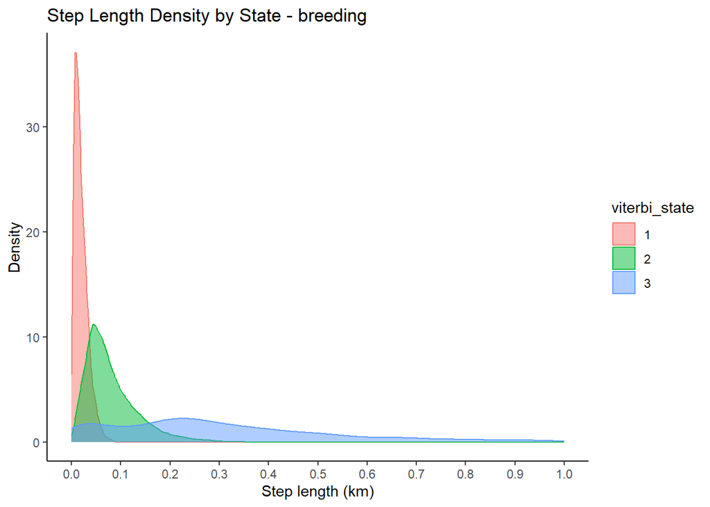

```r
hmm_data_breeding$viterbi_state <- factor(viterbi(hmm_breeding))

sp_breeding <- stateProbs(hmm_breeding)
colnames(sp_breeding) <- paste0("state_prob_", seq_len(ncol(sp_breeding)))

hmm_data_breeding <- cbind(hmm_data_breeding, sp_breeding)

write.csv(hmm_data_breeding, file.path(derived_data_dir, "hmm_data_breeding.csv"), row.names = FALSE)

# Inspect step-length distributions across the inferred states
ggplot(hmm_data_breeding, aes(x = step, color = viterbi_state, fill = viterbi_state)) +
  geom_density(alpha = 0.5) +
  labs(
    title = "Step Length Density by State - breeding",
    x = "Step length (km)",
    y = "Density"
  ) +
  theme_classic() +
  scale_x_continuous(
    limits = c(0, 1),
    breaks = seq(0, 1, by = 0.1)
  )
```

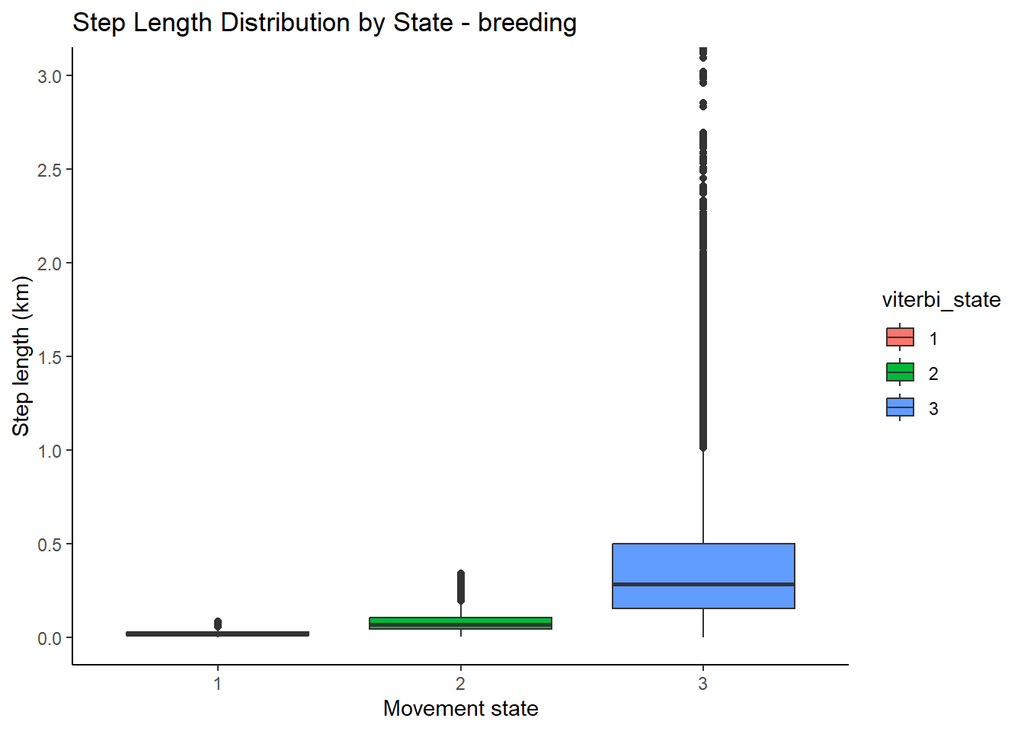

```r
ggplot(hmm_data_breeding, aes(x = viterbi_state, y = step, fill = viterbi_state)) +
  geom_boxplot() +
   labs(
    title = "Step Length Distribution by State - breeding",
    x = "Movement state",
    y = "Step length (km)"
  ) +
  theme_classic() +
  scale_y_continuous(breaks = seq(0, 3, by = 0.5))+
  coord_cartesian(ylim = c(0, 3))
```

#### Plot estimated state-dependent distributions

Inspect the fitted state-dependent distributions and the proportion of time in each state

```
## Decoding state sequence... DONE
```

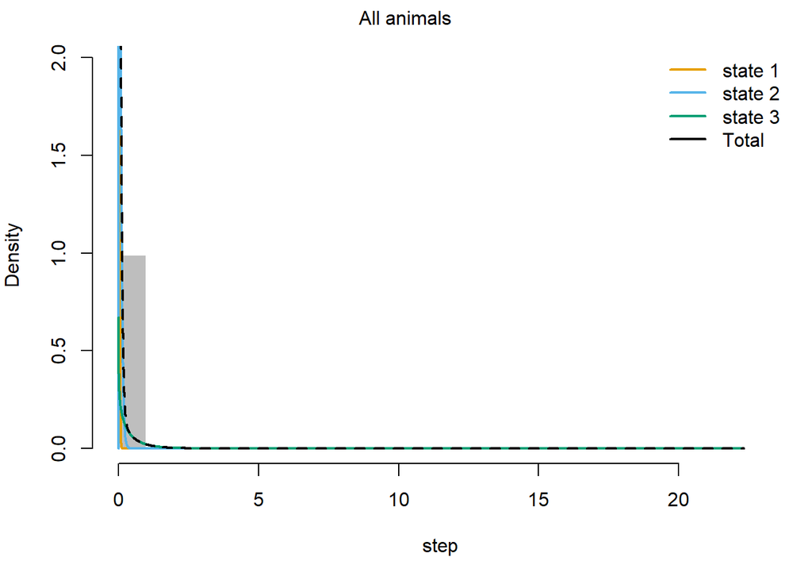

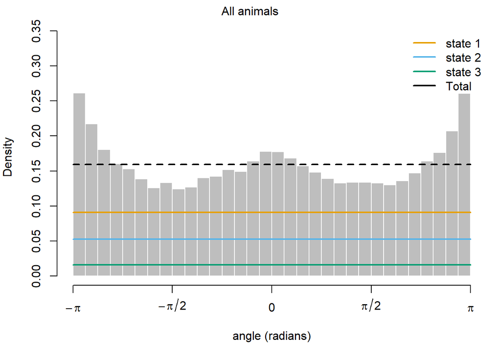

```r
plot(hmm_breeding, breaks = 25, ask = FALSE, plotTracks = FALSE)
```

```r
timeInStates(hmm_breeding)
```

```
##     state 1   state 2   state 3
## 1 0.5693711 0.3292392 0.1013898
```

### post-breeding

#### Model fitting

```r
# Specify the state-dependent distributions for step length and turning angle
dist <- list(step = "gamma", angle = "vm")

mean_displacement_post_breeding <- ifelse("post_breeding" %in% flight_displacement_summary$phen_phase,
                                          flight_displacement_summary$mean_displacement[flight_displacement_summary$phen_phase == "post_breeding"],
                                          flight_displacement_summary$mean_displacement[flight_displacement_summary$phen_phase == "Global"])

sd_displacement_post_breeding <- ifelse("post_breeding" %in% flight_displacement_summary$phen_phase,
                                        flight_displacement_summary$sd_displacement[flight_displacement_summary$phen_phase == "post_breeding"],
                                        flight_displacement_summary$sd_displacement[flight_displacement_summary$phen_phase == "Global"])


# Provide initial values for the 3-state HMM
par0_3_states <- list(
  step = c(0.01, 0.03, mean_displacement_post_breeding, 0.01, 0.010, sd_displacement_post_breeding),
  angle = c(0.01, 0.01, 0.01)
)

hmm_post_breeding <- fitHMM(
  hmm_data_post_breeding,
  nbStates = 3,
  dist = dist,
  retryFits = 0,
  Par0 = par0_3_states
)

print(hmm_post_breeding)
```

```
## Value of the maximum log-likelihood: 17773.79
##
##
## step parameters:
## ----------------
##         state 1    state 2   state 3
## mean 0.01416554 0.06775374 0.5207955
## sd   0.01038212 0.04477920 0.5912587
##
## angle parameters:
## -----------------
##                    state 1      state 2   state 3
## mean          0.000000e+00 0.0000000000 0.0000000
## concentration 1.241937e-11 0.0003062321 0.3526233
##
## Regression coeffs for the transition probabilities:
## ---------------------------------------------------
##                1 -> 2    1 -> 3   2 -> 1    2 -> 3   3 -> 1    3 -> 2
## (Intercept) -1.955242 -3.862944 -1.60374 -1.711315 -1.84526 0.2534524
##
## Transition probability matrix:
## ------------------------------
##            state 1   state 2    state 3
## state 1 0.86018822 0.1217426 0.01806917
## state 2 0.14556891 0.7237089 0.13072216
## state 3 0.06457692 0.5266676 0.40875550
##
## Initial distribution:
## ---------------------
##   state 1   state 2   state 3
## 0.4498553 0.3965831 0.1535617
```

#### Model outputs

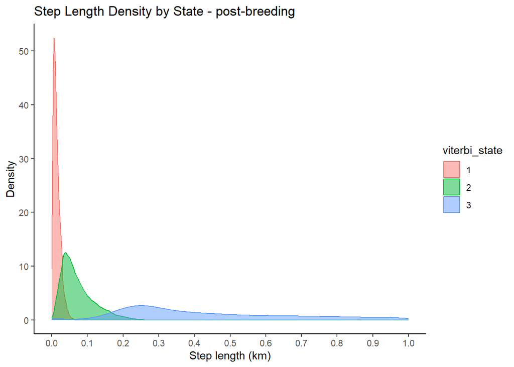

```r
hmm_data_post_breeding$viterbi_state <- factor(viterbi(hmm_post_breeding))

sp_post_breeding <- stateProbs(hmm_post_breeding)
colnames(sp_post_breeding) <- paste0("state_prob_", seq_len(ncol(sp_post_breeding)))

hmm_data_post_breeding <- cbind(hmm_data_post_breeding, sp_post_breeding)

write.csv(
  hmm_data_post_breeding,
  file.path(derived_data_dir, "hmm_data_post_breeding.csv"),
  row.names = FALSE
)

ggplot(hmm_data_post_breeding, aes(x = step, color = viterbi_state, fill = viterbi_state)) +
  geom_density(alpha = 0.5) +
  labs(
    title = "Step Length Density by State - post-breeding",
    x = "Step length (km)",
    y = "Density"
  ) +
  theme_classic() +
  scale_x_continuous(
    limits = c(0, 1),
    breaks = seq(0, 1, by = 0.1)
  )
```

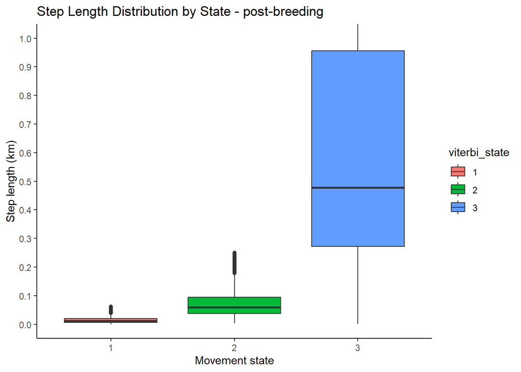

```r
ggplot(hmm_data_post_breeding, aes(x = viterbi_state, y = step, fill = viterbi_state)) +
  geom_boxplot() +
  labs(
    title = "Step Length Distribution by State - post-breeding",
    x = "Movement state",
    y = "Step length (km)"
  ) +
  theme_classic() +
  scale_y_continuous(breaks = seq(0, 1, by = 0.1)) +
  coord_cartesian(ylim = c(0, 1))
```

#### Plot estimated state-dependent distributions

Inspect the fitted state-dependent distributions and the proportion of time in each state

```
## Decoding state sequence... DONE
```

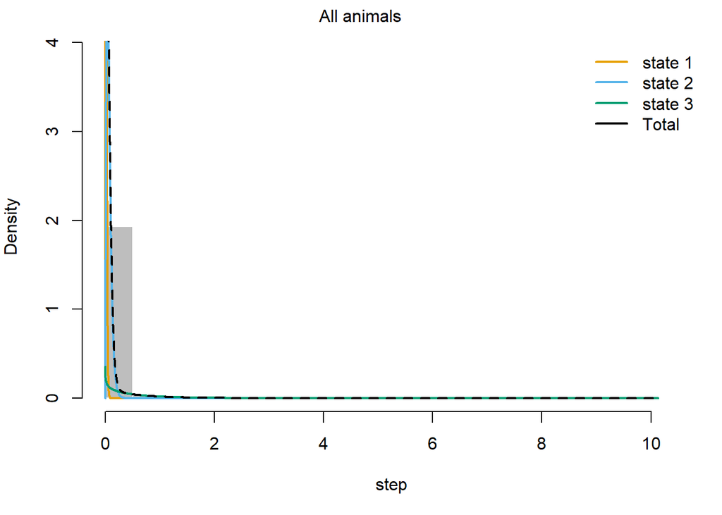

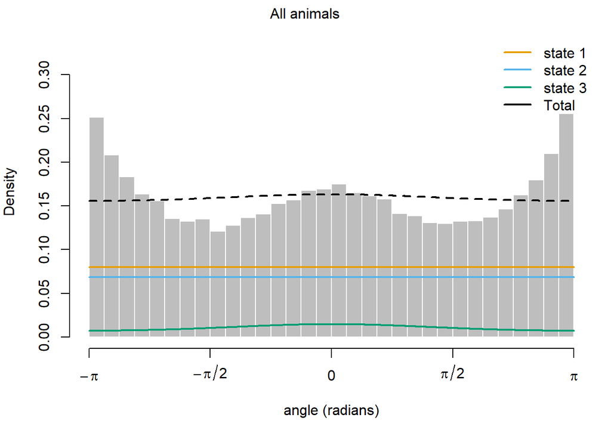

```r
plot(hmm_post_breeding, breaks = 25, ask = FALSE, plotTracks = FALSE)
```

```r
timeInStates(hmm_post_breeding)
```

```
##     state 1   state 2    state 3
## 1 0.5023688 0.4306522 0.06697903
```

### winter

#### Model fitting

Use boost-derived displacement to define biologically plausible starting values for the 3-state HMM fitted to winter data

```r
dist <- list(step = "gamma", angle = "vm")

mean_displacement_winter <- ifelse("winter" %in% flight_displacement_summary$phen_phase,
                                      flight_displacement_summary$mean_displacement[flight_displacement_summary$phen_phase == "winter"],
                                      flight_displacement_summary$mean_displacement[flight_displacement_summary$phen_phase == "Global"])

sd_displacement_winter <- ifelse("winter" %in% flight_displacement_summary$phen_phase,
                                      flight_displacement_summary$sd_displacement[flight_displacement_summary$phen_phase == "winter"],
                                      flight_displacement_summary$sd_displacement[flight_displacement_summary$phen_phase == "Global"])


# Provide initial values for the 3-state winter HMM
par0_3_states <- list(step = c(0.01, 0.030, mean_displacement_winter, 0.01, 0.010 , sd_displacement_winter), angle = c(0.01, 0.01, 0.01))

hmm_winter <- fitHMM(hmm_data_winter,
               nbStates = 3,
               dist = dist,
               retryFits = 0, # 30
               Par0 = par0_3_states)

print(hmm_winter)
```

```
## Value of the maximum log-likelihood: 11042.18
##
##
## step parameters:
## ----------------
##         state 1    state 2   state 3
## mean 0.01462577 0.04275253 0.6037846
## sd   0.01002513 0.02998120 0.7697321
##
## angle parameters:
## -----------------
##                    state 1    state 2      state 3
## mean          0.000000e+00 0.00000000 0.000000e+00
## concentration 2.528235e-11 0.07357883 4.793652e-07
##
## Regression coeffs for the transition probabilities:
## ---------------------------------------------------
##                1 -> 2    1 -> 3    2 -> 1    2 -> 3     3 -> 1    3 -> 2
## (Intercept) -1.979668 -2.199808 -1.960544 -1.720262 -0.3995453 0.1194878
##
## Transition probability matrix:
## ------------------------------
##           state 1   state 2    state 3
## state 1 0.8006793 0.1105859 0.08873479
## state 2 0.1066690 0.7576899 0.13564112
## state 3 0.2397191 0.4028245 0.35745635
##
## Initial distribution:
## ---------------------
##      state 1      state 2      state 3
## 5.514689e-01 2.731563e-30 4.485311e-01
```

#### Model outputs

Decode winter states and export the corresponding state probabilities

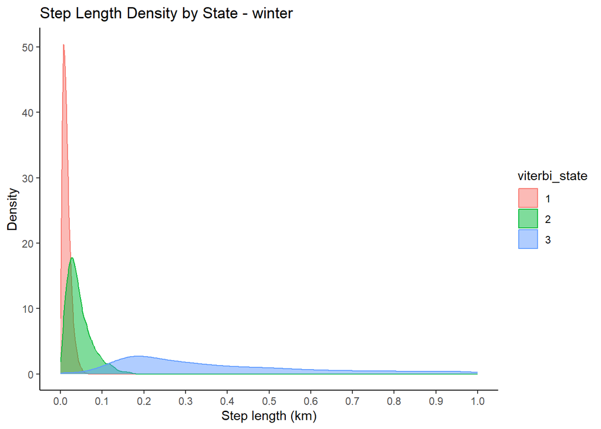

```r
hmm_data_winter$viterbi_state <- factor(viterbi(hmm_winter))

sp_winter <- stateProbs(hmm_winter)
colnames(sp_winter) <- paste0("state_prob_", seq_len(ncol(sp_winter)))

hmm_data_winter <- cbind(hmm_data_winter, sp_winter)

write.csv(hmm_data_winter, file.path(derived_data_dir, "hmm_data_winter.csv"), row.names = FALSE)

# Inspect step-length distributions across the inferred winter states
ggplot(hmm_data_winter, aes(x = step, color = viterbi_state, fill = viterbi_state)) +
  geom_density(alpha = 0.5) +
  labs(
    title = "Step Length Density by State - winter",
    x = "Step length (km)",
    y = "Density"
  ) +
  theme_classic() +
  scale_x_continuous(
    limits = c(0, 1),
    breaks = seq(0, 1, by = 0.1)
  )
```

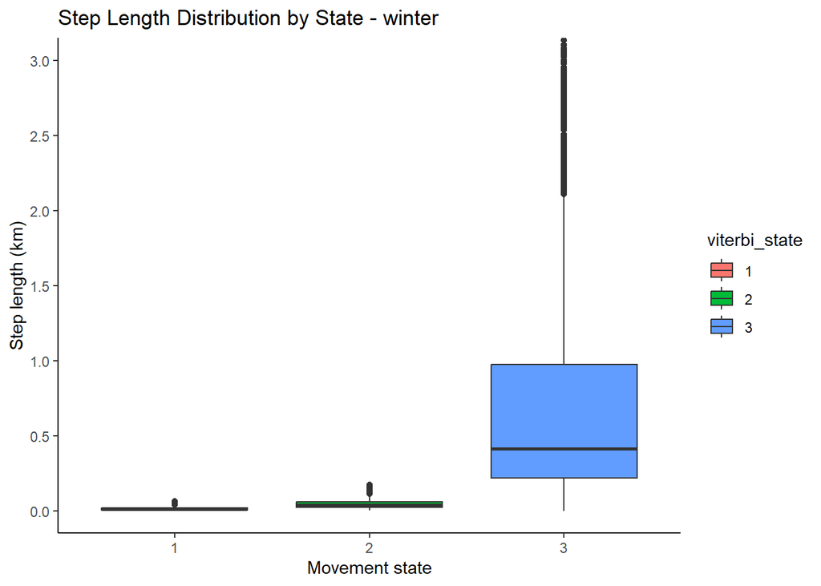

```r
ggplot(hmm_data_winter, aes(x = viterbi_state, y = step, fill = viterbi_state)) +
  geom_boxplot() +
   labs(
    title = "Step Length Distribution by State - winter",
    x = "Movement state",
    y = "Step length (km)"
  ) +
  theme_classic() +
  scale_y_continuous(breaks = seq(0, 3, by = 0.5))+
  coord_cartesian(ylim = c(0, 3))
```

#### Plot estimated state-dependent distributions

Inspect the fitted state-dependent distributions and the proportion of time in each state

```
## Decoding state sequence... DONE
```

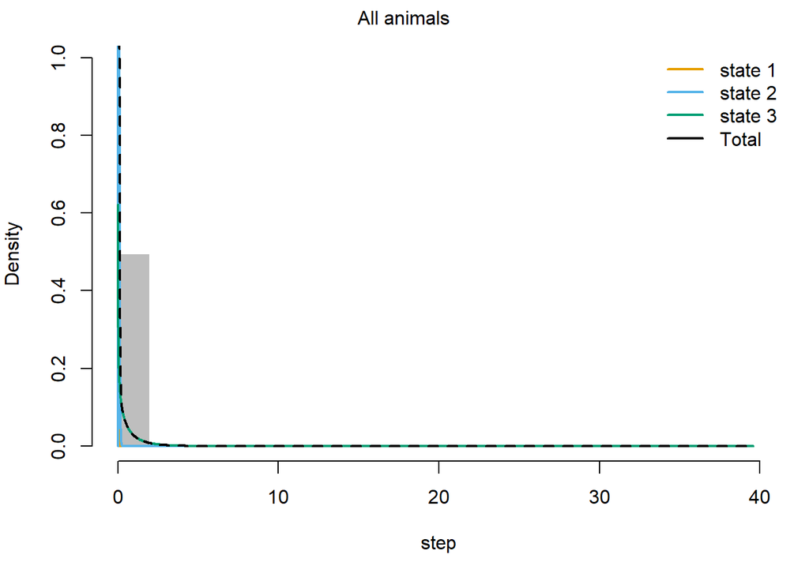

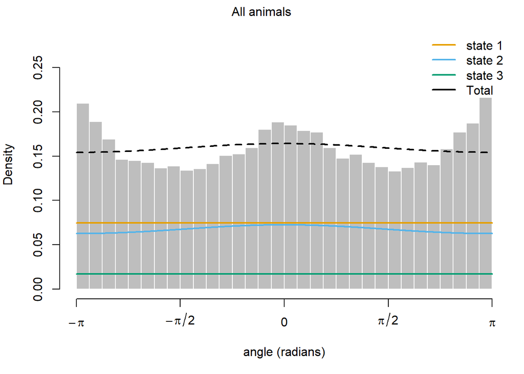

```r
plot(hmm_winter, breaks = 25, ask = FALSE, plotTracks = FALSE)
```

```r
timeInStates(hmm_winter)
```

```
##     state 1   state 2   state 3
## 1 0.4690246 0.4239557 0.1070196
```

### Merge phases

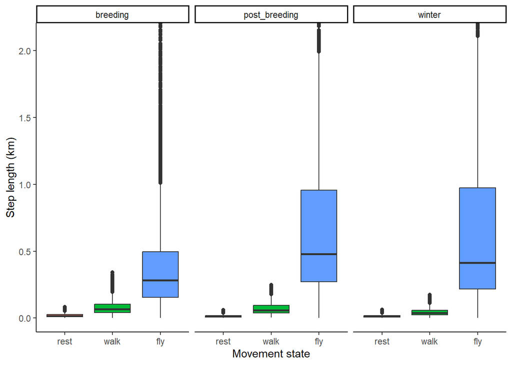

```r
hmm_data_breeding <- read.csv(file.path(derived_data_dir, "hmm_data_breeding.csv"), sep = ",")
hmm_data_post_breeding <- read.csv(file.path(derived_data_dir, "hmm_data_post_breeding.csv"), sep = ",")
hmm_data_winter <- read.csv(file.path(derived_data_dir, "hmm_data_winter.csv"), sep = ",")
hmm_data_other <- read.csv(file.path(derived_data_dir, "hmm_data_other.csv"), sep = ",")

data_hmm_all <- bind_rows(
  hmm_data_breeding,
  hmm_data_post_breeding,
  hmm_data_winter,
  hmm_data_other
)

data_hmm_all <- data_hmm_all %>%
  mutate(
    state_label = factor(
      viterbi_state,
      levels = c("1", "2", "3"),
      labels = c("rest", "walk", "fly")
    ),
    phen_phase = factor(
      phen_phase,
      levels = c("breeding", "post_breeding", "winter", "other")
    )
  )

# Compare state-dependent step lengths between phases
plot_step_length_distributions <- data_hmm_all %>%
  filter(phen_phase != "other") %>%
  ggplot(aes(x = state_label, y = step, fill = state_label)) +
  geom_boxplot() +
  facet_wrap(~ phen_phase) +
  labs(
    x = "Movement state",
    y = "Step length (km)"
  ) +
  theme_classic() +
  theme(legend.position = "none") +
  scale_y_continuous(breaks = seq(0, 2, by = 0.5)) +
  coord_cartesian(ylim = c(0, 2.1))

print(plot_step_length_distributions)
```

## Calculate daily flight distance

### Add correction factor to distances

Apply the boost-derived correction factor to HMM step lengths to approximate path length more accurately at the 30-min scale

```r
data_hmm_all_corrected <- data_hmm_all %>%
  mutate(
    correction_factor = ifelse(
      viterbi_state == 3,
      ifelse(
        phen_phase %in% summary_correction_factor$phen_phase,
        summary_correction_factor$median_correction_factor[
          match(phen_phase, summary_correction_factor$phen_phase)
        ],
        summary_correction_factor$median_correction_factor[
          summary_correction_factor$phen_phase == "Global"
        ]
      ),
      NA_real_
    ),
    corrected_distance = ifelse(
      viterbi_state == 3,
      step * correction_factor,
      NA_real_
    )
  )

write.csv(data_hmm_all_corrected,file.path(derived_data_dir, "data_hmm_all_corrected.csv"), row.names = FALSE)

# Export the movement dataset used in distance and height summaries
movement_data <- data_hmm_all_corrected %>%
  dplyr::select(
    Individual_ID,
    sequence_id = ID,
    step,
    angle,
    UTC_datetime,
    phen_phase,
    tod,
    acquisition_mode,

    ground_elevation,
    altitude_above_ground,
    viterbi_state,
    state_label,
    state_prob_1,
    state_prob_2,
    state_prob_3,
    correction_factor,
    corrected_distance,

    satcount,
    U_bat_mV,
    bat_soc_pct,
    solar_I_mA,
    hdop,
    Altitude_m,
    speed_km_h,
    direction_deg,
    int_temperature_C,
    mag_x, mag_y, mag_z,
    acc_x, acc_y, acc_z
  )%>%
  mutate(
    acquisition_mode = dplyr::recode(
      acquisition_mode,
      "boost_start" = "boost",
      "boost_end"   = "boost",
      "burst_end"   = "burst"
    )
  )%>%
  arrange(Individual_ID, UTC_datetime)

write.csv(movement_data,file.path(results_dir, "Movement_data.csv"), row.names = FALSE)
```

### Descriptive summaries of corrected flight distance by phenological phase and daytime period

```r
# Load corrected movement data
data_flight_distance_all <- read.csv(
  file.path(results_dir, "Movement_data.csv"),
  sep = ","
)

# Build continuous 30-min sequences within each original sequence and time-of-day class
sequence_distance_summary <- data_flight_distance_all %>%
  filter(phen_phase != "other") %>%
  mutate(
    UTC_datetime = as.POSIXct(UTC_datetime, tz = "UTC")
  ) %>%
  group_by(sequence_id, tod) %>%
  mutate(
    time_diff = as.numeric(difftime(UTC_datetime, lag(UTC_datetime), units = "mins")),
    new_sequence = ifelse(is.na(time_diff) | time_diff > 35, 1, 0),
    new_sequence_id = cumsum(new_sequence),
    global_sequence_id = paste(sequence_id, tod, new_sequence_id, sep = "_")
  ) %>%
  ungroup() %>%
  group_by(global_sequence_id, phen_phase, tod, Individual_ID) %>%
  summarise(
    hourly_distance_km = sum(corrected_distance[viterbi_state == 3], na.rm = TRUE) / (n() * 0.5),
    n_fixes = dplyr::n(),
    .groups = "drop"
  )

# Descriptive hourly summaries by phenological phase and daytime period
flight_distance_hourly_summary <- sequence_distance_summary %>%
  group_by(phen_phase, tod) %>%
  summarise(
    n_individuals = n_distinct(Individual_ID),
    n_sequences = dplyr::n(),
    mean_hourly_distance_km = mean(hourly_distance_km, na.rm = TRUE),
    sd_hourly_distance_km = sd(hourly_distance_km, na.rm = TRUE),
    median_hourly_distance_km = median(hourly_distance_km, na.rm = TRUE),
    q25_hourly_distance_km = quantile(hourly_distance_km, 0.25, na.rm = TRUE),
    q75_hourly_distance_km = quantile(hourly_distance_km, 0.75, na.rm = TRUE),
    .groups = "drop"
  ) %>%
  mutate(
    species = "Tetrax tetrax",
    phen_phase = factor(phen_phase, levels = c("breeding", "post_breeding", "winter")),
    tod = factor(tod, levels = c("dawn", "day", "dusk", "night"))
  ) %>%
  arrange(phen_phase, tod) %>%
  relocate(species, .before = 1)

tagList(
  h3("Descriptive hourly flight distance by phenological phase and daytime period"),
  datatable(
    flight_distance_hourly_summary,
    options = list(scrollX = TRUE, scrollY = TRUE, pageLength = 12)
  )
)
```

### Descriptive hourly flight distance by phenological phase and daytime period

|  | species | phen_phase | tod | n_individuals | n_sequences | mean_hourly_distance_km | sd_hourly_distance_km | median_hourly_distance_km | q25_hourly_distance_km | q75_hourly_distance_km |
| --- | --- | --- | --- | --- | --- | --- | --- | --- | --- | --- |
| 1 | Tetrax tetrax | breeding | dawn | 31 | 1898 | 0.3049124658046909 | 0.7393501592428002 | 0 | 0 | 0.3498125970908177 |
| 2 | Tetrax tetrax | breeding | day | 31 | 2498 | 0.09431985318554775 | 0.262166229332762 | 0 | 0 | 0.09800026775813432 |
| 3 | Tetrax tetrax | breeding | dusk | 30 | 1902 | 0.1327523864083953 | 0.5384136846457441 | 0 | 0 | 0 |
| 4 | Tetrax tetrax | breeding | night | 30 | 2408 | 0.1637548908774152 | 0.880338678283319 | 0 | 0 | 0 |
| 5 | Tetrax tetrax | post_breeding | dawn | 27 | 2353 | 0.3497253336722924 | 0.6518618139757586 | 0 | 0 | 0.484849996745313 |
| 6 | Tetrax tetrax | post_breeding | day | 27 | 3577 | 0.0699622033163955 | 0.1813914599393688 | 0 | 0 | 0.06438706857194812 |
| 7 | Tetrax tetrax | post_breeding | dusk | 26 | 2501 | 0.2424529925446418 | 0.4643538312864307 | 0 | 0 | 0.350030274618207 |
| 8 | Tetrax tetrax | post_breeding | night | 26 | 2497 | 0.09264137515157189 | 0.689202785090738 | 0 | 0 | 0 |
| 9 | Tetrax tetrax | winter | dawn | 21 | 1707 | 0.2966623006449405 | 0.716271620223634 | 0 | 0 | 0.2335238839915477 |
| 10 | Tetrax tetrax | winter | day | 22 | 2504 | 0.309750141751145 | 0.5797714113327821 | 0.0762956808958542 | 0 | 0.3719676889931518 |

[output cut: 2 more lines]

```r
# Define representative calendar windows for the focal phenological phases
manual_dates <- tibble::tibble(
  phen_phase = c("breeding", "post_breeding", "winter"),
  start_date = as.Date(c("2025-04-15", "2025-07-15", "2025-12-15")),
  end_date   = as.Date(c("2025-05-15", "2025-09-15", "2026-02-15"))
)

# Load a dataset that still contains geographic coordinates
movement_data_with_coords <- read.csv(
  file.path(derived_data_dir, "data_hmm_all_corrected.csv"),
  sep = ","
)

# Prepare one representative location and three representative dates per phase
phases_days <- manual_dates %>%
  left_join(
    movement_data_with_coords %>%
      filter(phen_phase != "other") %>%
      group_by(phen_phase) %>%
      summarise(
        lon = mean(X, na.rm = TRUE),
        lat = mean(Y, na.rm = TRUE),
        .groups = "drop"
      ),
    by = "phen_phase"
  ) %>%
  mutate(
    mid_date = start_date + floor((end_date - start_date) / 2),
    sim_date = pmap(
      list(start_date, mid_date, end_date),
      ~ c(..1, ..2, ..3)
    )
  ) %>%
  dplyr::select(phen_phase, sim_date, lon, lat) %>%
  tidyr::unnest(sim_date) %>%
  mutate(day_id = row_number())

# Calculate sunrise and sunset for each simulated day
sun_times <- suncalc::getSunlightTimes(
  data = phases_days %>%
    transmute(
      date = sim_date,
      lat = lat,
      lon = lon
    ),
  keep = c("sunrise", "sunset"),
  tz = "UTC"
) %>%
  mutate(day_id = phases_days$day_id) %>%
  dplyr::select(day_id, sunrise, sunset)

# Simulate 30-min points and classify daytime period directly
tod_duration_summary <- phases_days %>%
  left_join(sun_times, by = "day_id") %>%
  tidyr::expand_grid(step = 0:47) %>%
  mutate(
    UTC_datetime = as.POSIXct(sim_date, tz = "UTC") + minutes(30 * step),
    tod = case_when(
      UTC_datetime >= sunrise - hours(1) &
        UTC_datetime <= sunrise + hours(1) ~ "dawn",
      UTC_datetime >= sunset - hours(1) &
        UTC_datetime <= sunset + hours(1) ~ "dusk",
      UTC_datetime > sunrise + hours(1) &
        UTC_datetime < sunset - hours(1) ~ "day",
      TRUE ~ "night"
    ),
    tod = factor(tod, levels = c("dawn", "day", "dusk", "night"))
  ) %>%
  group_by(phen_phase, tod) %>%
  summarise(
    duration_hours = n() * 0.5 / 3,
    .groups = "drop"
  ) %>%
  mutate(
    phen_phase = factor(phen_phase, levels = c("breeding", "post_breeding", "winter")),
    tod = factor(tod, levels = c("dawn", "day", "dusk", "night"))
  ) %>%
  arrange(phen_phase, tod)

tagList(
  h3("Average TOD duration by phenological phase"),
  datatable(
    tod_duration_summary,
    options = list(scrollX = TRUE, scrollY = TRUE, pageLength = 12)
  )
)
```

### Average TOD duration by phenological phase

|  | phen_phase | tod | duration_hours |
| --- | --- | --- | --- |
| 1 | breeding | dawn | 2 |
| 2 | breeding | day | 12 |
| 3 | breeding | dusk | 2 |
| 4 | breeding | night | 8 |
| 5 | post_breeding | dawn | 2 |
| 6 | post_breeding | day | 11.5 |
| 7 | post_breeding | dusk | 2 |
| 8 | post_breeding | night | 8.5 |
| 9 | winter | dawn | 2 |
| 10 | winter | day | 8 |

[output cut: 2 more lines]

```r
# Convert hourly descriptive summaries into descriptive daily contributions
flight_distance_daily_tod_summary <- flight_distance_hourly_summary %>%
  left_join(tod_duration_summary, by = c("phen_phase", "tod")) %>%
  mutate(
    mean_daily_distance_km = mean_hourly_distance_km * duration_hours,
    sd_daily_distance_km = sd_hourly_distance_km * duration_hours,
    median_daily_distance_km = median_hourly_distance_km * duration_hours,
    q25_daily_distance_km = q25_hourly_distance_km * duration_hours,
    q75_daily_distance_km = q75_hourly_distance_km * duration_hours
  ) %>%
  arrange(phen_phase, tod)

# Compute one descriptive total daily distance per phenological phase
flight_distance_daily_total <- flight_distance_daily_tod_summary %>%
  group_by(species, phen_phase) %>%
  summarise(
    tod = "total_24h",
    n_individuals = max(n_individuals, na.rm = TRUE),
    n_sequences = sum(n_sequences, na.rm = TRUE),
    mean_hourly_distance_km = NA_real_,
    sd_hourly_distance_km = NA_real_,
    median_hourly_distance_km = NA_real_,
    q25_hourly_distance_km = NA_real_,
    q75_hourly_distance_km = NA_real_,
    duration_hours = 24,
    mean_daily_distance_km = sum(mean_daily_distance_km, na.rm = TRUE),
    sd_daily_distance_km = sqrt(sum(sd_daily_distance_km^2, na.rm = TRUE)),
    median_daily_distance_km = sum(median_daily_distance_km, na.rm = TRUE),
    q25_daily_distance_km = sum(q25_daily_distance_km, na.rm = TRUE),
    q75_daily_distance_km = sum(q75_daily_distance_km, na.rm = TRUE),
    .groups = "drop"
  )

# Combine TOD-specific contributions with the phase-level total
flight_distance_daily_summary <- bind_rows(
  flight_distance_daily_tod_summary,
  flight_distance_daily_total
) %>%
  mutate(
    phen_phase = factor(phen_phase, levels = c("breeding", "post_breeding", "winter")),
    tod = factor(tod, levels = c("dawn", "day", "dusk", "night", "total_24h"))
  ) %>%
  arrange(phen_phase, tod)

tagList(
  h3("Descriptive daily flight distance by phenological phase and daytime period"),
  datatable(
    flight_distance_daily_summary,
    options = list(scrollX = TRUE, scrollY = TRUE, pageLength = 12)
  )
)
```

### Descriptive daily flight distance by phenological phase and daytime period

|  | species | phen_phase | tod | n_individuals | n_sequences | mean_hourly_distance_km | sd_hourly_distance_km | median_hourly_distance_km | q25_hourly_distance_km | q75_hourly_distance_km | duration_hours | mean_daily_distance_km | sd_daily_distance_km | median_daily_distance_km | q25_daily_distance_km | q75_daily_distance_km |
| --- | --- | --- | --- | --- | --- | --- | --- | --- | --- | --- | --- | --- | --- | --- | --- | --- |
| 1 | Tetrax tetrax | breeding | dawn | 31 | 1898 | 0.3049124658046909 | 0.7393501592428002 | 0 | 0 | 0.3498125970908177 | 2 | 0.6098249316093818 | 1.4787003184856 | 0 | 0 | 0.6996251941816355 |
| 2 | Tetrax tetrax | breeding | day | 31 | 2498 | 0.09431985318554775 | 0.262166229332762 | 0 | 0 | 0.09800026775813432 | 12 | 1.131838238226573 | 3.145994751993144 | 0 | 0 | 1.176003213097612 |
| 3 | Tetrax tetrax | breeding | dusk | 30 | 1902 | 0.1327523864083953 | 0.5384136846457441 | 0 | 0 | 0 | 2 | 0.2655047728167907 | 1.076827369291488 | 0 | 0 | 0 |
| 4 | Tetrax tetrax | breeding | night | 30 | 2408 | 0.1637548908774152 | 0.880338678283319 | 0 | 0 | 0 | 8 | 1.310039127019322 | 7.042709426266552 | 0 | 0 | 0 |
| 5 | Tetrax tetrax | breeding | total_24h | 31 | 8706 |  |  |  |  |  | 24 | 3.317207069672067 | 7.927367208445487 | 0 | 0 | 1.875628407279248 |
| 6 | Tetrax tetrax | post_breeding | dawn | 27 | 2353 | 0.3497253336722924 | 0.6518618139757586 | 0 | 0 | 0.484849996745313 | 2 | 0.6994506673445847 | 1.303723627951517 | 0 | 0 | 0.969699993490626 |
| 7 | Tetrax tetrax | post_breeding | day | 27 | 3577 | 0.0699622033163955 | 0.1813914599393688 | 0 | 0 | 0.06438706857194812 | 11.5 | 0.8045653381385481 | 2.08600178930274 | 0 | 0 | 0.7404512885774034 |
| 8 | Tetrax tetrax | post_breeding | dusk | 26 | 2501 | 0.2424529925446418 | 0.4643538312864307 | 0 | 0 | 0.350030274618207 | 2 | 0.4849059850892835 | 0.9287076625728614 | 0 | 0 | 0.700060549236414 |
| 9 | Tetrax tetrax | post_breeding | night | 26 | 2497 | 0.09264137515157189 | 0.689202785090738 | 0 | 0 | 0 | 8.5 | 0.7874516887883611 | 5.858223673271272 | 0 | 0 | 0 |
| 10 | Tetrax tetrax | post_breeding | total_24h | 27 | 10928 |  |  |  |  |  | 24 | 2.776373679360777 | 6.421244528255469 | 0 | 0 | 2.410211831304443 |

[output cut: 5 more lines]

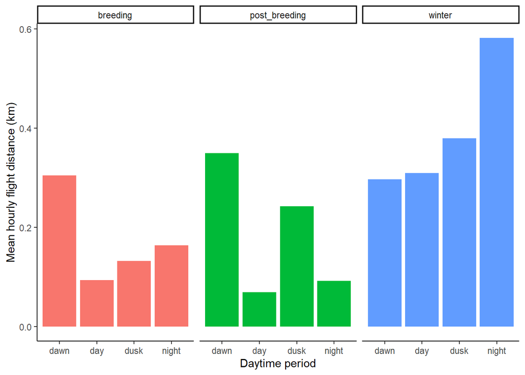

```r
write.csv(
  flight_distance_daily_summary,
  file.path(results_dir, "Flight_distance_summary.csv"),
  row.names = FALSE
)


plot_flight_distance_descriptive_hourly <- flight_distance_hourly_summary %>%
  ggplot(aes(x = tod, y = mean_hourly_distance_km, fill = phen_phase)) +
  geom_col(position = "dodge") +
  facet_wrap(~ phen_phase) +
  labs(
    x = "Daytime period",
    y = "Mean hourly flight distance (km)"
  ) +
  theme_classic() +
  theme(legend.position = "none") +
  scale_fill_manual(
    values = c(
      "breeding" = "#F8766D",
      "post_breeding" = "#00BA38",
      "winter" = "#619CFF"
    )
  )

plot_flight_distance_descriptive_hourly
```

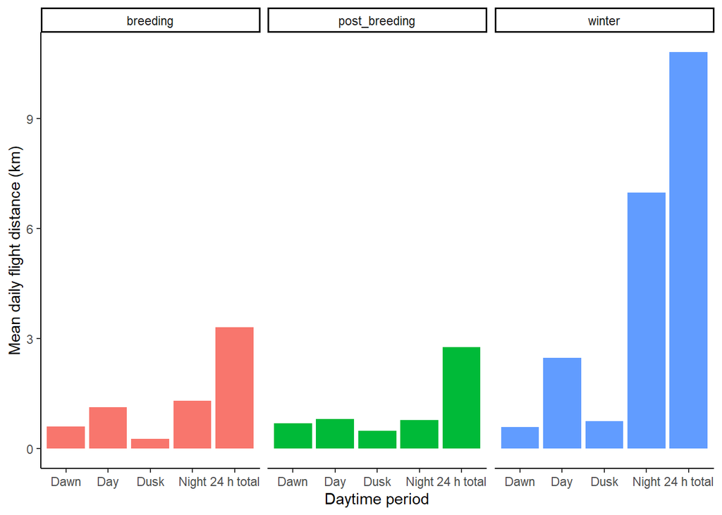

```r
ggsave(
  file.path(results_dir, "plot_flight_distance_descriptive_hourly.png"),
  plot_flight_distance_descriptive_hourly,
  width = 15,
  height = 10,
  units = "cm",
  dpi = 600
)

plot_flight_distance_descriptive_daily <- flight_distance_daily_summary %>%
  ggplot(aes(x = tod, y = mean_daily_distance_km, fill = phen_phase)) +
  geom_col(position = "dodge") +
  facet_wrap(~ phen_phase) +
  labs(
    x = "Daytime period",
    y = "Mean daily flight distance (km)"
  ) +
  theme_classic() +
  theme(legend.position = "none") +
  scale_x_discrete(
    labels = c(
      dawn = "Dawn",
      day = "Day",
      dusk = "Dusk",
      night = "Night",
      total_24h = "24 h total"
    )
  ) +
  scale_fill_manual(
    values = c(
      "breeding" = "#F8766D",
      "post_breeding" = "#00BA38",
      "winter" = "#619CFF"
    )
  )

plot_flight_distance_descriptive_daily
```

```r
ggsave(
  file.path(results_dir, "plot_flight_distance_descriptive_daily.png"),
  plot_flight_distance_descriptive_daily,
  width = 15,
  height = 10,
  units = "cm",
  dpi = 600
)
```

# Flight height

### Data preparation and error calculation

Prepare the altitude dataset, identify phase-specific outliers, and estimate device- and acquisition-specific altitude error

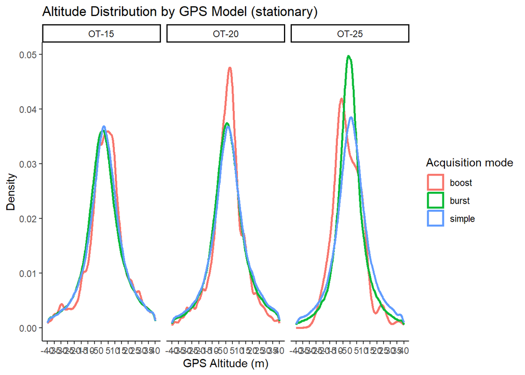

```r
# List prepared per-individual datasets
files <- list.files(path = derived_data_dir, pattern = "Data_Prep\\.csv$")

# Store all valid altitude records across individuals
data_list <- list()

for (i in files) {

  x <- read.csv(file.path(derived_data_dir, i), sep = ",")

  x$UTC_datetime <- as.POSIXct(x$UTC_datetime, format = "%Y-%m-%d %H:%M:%OS", tz = "GMT")
  x <- x[order(x$UTC_datetime),]

  # Retain points previously classified as valid during the preparation workflow
  x <- x[is.na(x$filter) | x$filter == "OK", ]

  # Harmonise identifier types before binding all individuals
  x <- x %>%
    mutate(
      device_id = as.character(device_id),
      Individual_ID = as.character(Individual_ID)
    )

  # Remove records without behavioural classification
  x <- x[!is.na(x$behavior), ]

  data_list[[length(data_list) + 1]] <- x
}

# Merge all individuals and harmonise acquisition-mode labels
data_height_complete <- bind_rows(data_list) %>%
  mutate(
    acquisition_mode = dplyr::recode(
      acquisition_mode,
      "boost_start" = "boost",
      "boost_end"   = "boost",
      "burst_end"   = "burst"
    )
  ) %>%
  filter(!is.na(altitude_above_ground), !is.na(acquisition_mode))

# Inspect the stationary altitude distribution by device and acquisition mode
ggplot(
  data_height_complete[data_height_complete$behavior == "stationary" & !is.na(data_height_complete$altitude_above_ground), ],
  aes(x = altitude_above_ground, color = acquisition_mode)
) +
  geom_density(linewidth = 1) +
  scale_x_continuous(
    limits = c(-40, 40),
    breaks = seq(-40, 40, by = 5)
  ) +
  facet_wrap(~ gps_model) +
  labs(
    title = "Altitude Distribution by GPS Model (stationary)",
    x = "GPS Altitude (m)",
    y = "Density",
    color = "Acquisition mode"
  ) +
  theme_classic()
```

```r
# Define empirical outlier limits separately for stationary and flight records
stationary_altitude_limits <- data_height_complete %>%
  filter(behavior == "stationary") %>%
  group_by(gps_brand, gps_model) %>%
  summarise(
    P2.5  = quantile(altitude_above_ground, 0.025, na.rm = TRUE),
    P97.5 = quantile(altitude_above_ground, 0.975, na.rm = TRUE),
    .groups = "drop"
  )

flight_altitude_limits <- data_height_complete %>%
  filter(behavior == "flight") %>%
  group_by(gps_brand, gps_model, phen_phase) %>%
  summarise(
    P2.5  = quantile(altitude_above_ground, 0.025, na.rm = TRUE),
    P97.5 = quantile(altitude_above_ground, 0.975, na.rm = TRUE),
    .groups = "drop"
  )

# Flag stationary outliers using device-specific empirical limits
data_height <- data_height_complete %>%
  left_join(stationary_altitude_limits, by = c("gps_brand", "gps_model")) %>%
  mutate(
    outlier_height = case_when(
      behavior == "stationary" &
        (altitude_above_ground < P2.5 | altitude_above_ground > P97.5) ~ "yes",
      TRUE ~ "no"
    )
  ) %>%
  dplyr::select(-P2.5, -P97.5)

# Flag flight outliers using phase-specific empirical limits
data_height <- data_height %>%
  left_join(flight_altitude_limits, by = c("gps_brand", "gps_model", "phen_phase")) %>%
  mutate(
    outlier_height = case_when(
      behavior == "flight" &
        (altitude_above_ground < P2.5 | altitude_above_ground > P97.5) ~ "yes",
      TRUE ~ outlier_height
    )
  ) %>%
  dplyr::select(-P2.5, -P97.5)

# Prepare stationary data used to quantify GPS vertical error
stationary_height_data <- data_height %>%
  filter(behavior == "stationary", outlier_height == "no") %>%
  group_by(gps_brand, gps_model, acquisition_mode) %>%
  mutate(
    residual_to_median = altitude_above_ground - median(altitude_above_ground, na.rm = TRUE),
    abs_dev_from_median = abs(residual_to_median),
    abs_error = abs(altitude_above_ground)
  ) %>%
  ungroup()

# Summarise trueness, precision, and accuracy metrics for stationary fixes
device_error <- stationary_height_data %>%
  group_by(gps_brand, gps_model, acquisition_mode) %>%
  summarise(
    n_stationary_fixes = dplyr::n(),
    n_individuals = n_distinct(Individual_ID),
    trueness_mean_signed_error_m = mean(altitude_above_ground, na.rm = TRUE),
    trueness_median_signed_error_m = median(altitude_above_ground, na.rm = TRUE),
    precision_sd_m = sd(residual_to_median, na.rm = TRUE),
    precision_mean_abs_dev_m = mean(abs_dev_from_median, na.rm = TRUE),
    precision_median_abs_dev_m = median(abs_dev_from_median, na.rm = TRUE),
    precision_q95_abs_dev_m = quantile(abs_dev_from_median, 0.95, na.rm = TRUE),
    precision_rmse_m = sqrt(mean(residual_to_median^2, na.rm = TRUE)),
    accuracy_mean_abs_error_m = mean(abs_error, na.rm = TRUE),
    accuracy_median_abs_error_m = median(abs_error, na.rm = TRUE),
    accuracy_q95_abs_error_m = quantile(abs_error, 0.95, na.rm = TRUE),
    accuracy_rmse_m = sqrt(mean(altitude_above_ground^2, na.rm = TRUE)),
    .groups = "drop"
  ) %>%
  mutate(species = "Tetrax tetrax") %>%
  relocate(species, .before = 1)

tagList(
  h3("GPS vertical error metrics"),
  datatable(device_error, options = list(scrollX = TRUE, pageLength = 10))
)
```

### GPS vertical error metrics

|  | species | gps_brand | gps_model | acquisition_mode | n_stationary_fixes | n_individuals | trueness_mean_signed_error_m | trueness_median_signed_error_m | precision_sd_m | precision_mean_abs_dev_m | precision_median_abs_dev_m | precision_q95_abs_dev_m | precision_rmse_m | accuracy_mean_abs_error_m | accuracy_median_abs_error_m | accuracy_q95_abs_error_m | accuracy_rmse_m |
| --- | --- | --- | --- | --- | --- | --- | --- | --- | --- | --- | --- | --- | --- | --- | --- | --- | --- |
| 1 | Tetrax tetrax | Ornitela | OT-15 | boost | 19522 | 8 | 4.03348088389036 | 3.78900146484375 | 16.87694980073388 | 12.03808105002904 | 7.7794952392578 | 38.75599670410155 | 16.87828825691226 | 12.51741665243284 | 8.508499145507809 | 39.4639892578125 | 17.35182446712143 |
| 2 | Tetrax tetrax | Ornitela | OT-15 | burst | 222693 | 14 | 2.020558340892612 | 1.3699951171875 | 17.00214093286361 | 12.28826878766549 | 8.4320068359375 | 38.52940673828121 | 17.01454468187109 | 12.35324636776947 | 8.41400146484375 | 38.7174011230469 | 17.12174506971474 |
| 3 | Tetrax tetrax | Ornitela | OT-15 | simple | 256899 | 18 | 2.763759115105068 | 2.38299560546875 | 17.02667495682368 | 12.30057088340165 | 8.43600463867185 | 38.62412109374994 | 17.03089875628222 | 12.50161781569557 | 8.66299438476562 | 39 | 17.24948973282373 |
| 4 | Tetrax tetrax | Ornitela | OT-20 | boost | 23508 | 6 | 2.413294642397959 | 2.201492309570315 | 13.87735875773699 | 9.742844143955606 | 6.431503295898435 | 30.98990173339839 | 13.87867984240989 | 9.968613038932018 | 6.570510864257815 | 30.58995666503909 | 14.08534291279236 |
| 5 | Tetrax tetrax | Ornitela | OT-20 | burst | 161895 | 12 | 2.374865412852738 | 1.656982421875 | 15.8938203044418 | 11.48915515311649 | 7.927001953125 | 35.89933166503906 | 15.90997547152543 | 11.58962562297368 | 8 | 36.20697937011723 | 16.07021932784273 |
| 6 | Tetrax tetrax | Ornitela | OT-20 | simple | 192466 | 14 | 2.847305284215327 | 2.25750732421875 | 16.62681510449272 | 12.09726246881399 | 8.35650634765625 | 37.32449340820315 | 16.63722951064625 | 12.27865075971413 | 8.53799438476562 | 37.64174652099607 | 16.868808242962 |
| 7 | Tetrax tetrax | Ornitela | OT-25 | boost | 211 | 2 | -0.7534489202273403 | -2.79000854492188 | 11.94488873689089 | 8.90304073677244 | 6.4019775390625 | 26.13198852539068 | 12.08932304853323 | 9.107656759108414 | 7.12298583984375 | 23.3729858398438 | 11.94034513497212 |
| 8 | Tetrax tetrax | Ornitela | OT-25 | burst | 190604 | 4 | 0.242288836887287 | -0.2748565673828125 | 11.50543300261211 | 8.314335168389913 | 5.769149780273438 | 25.74076843261723 | 11.51701929511603 | 8.317926186909443 | 5.77900695800781 | 25.69863510131835 | 11.50795368236236 |
| 9 | Tetrax tetrax | Ornitela | OT-25 | simple | 44002 | 4 | 1.458601860787444 | 1.05849456787109 | 13.40800046705542 | 10.0692488970006 | 7.424491882324225 | 29.40734405517577 | 13.4138166370558 | 10.11421324776431 | 7.44400024414062 | 29.53977966308597 | 13.48695333702177 |

```r
write.csv(device_error, file.path(results_dir, "GPS_error_metrics.csv"), row.names = FALSE)

# Append device-specific error terms to each record
data_height <- data_height %>%
  left_join(device_error, by = c("gps_brand", "gps_model", "acquisition_mode"))

# Export the height dataset used in the altitude analyses
data_height <- data_height %>%
  dplyr::select(
    Individual_ID,
    UTC_datetime,
    phen_phase,
    tod,
    acquisition_mode,

    behavior,
    ground_elevation,
    altitude_above_ground,
    gps_model,
    gps_model_full,
    outlier_height,
    n_stationary_fixes,
    n_individuals,
    trueness_median_signed_error_m,
    precision_sd_m,

    satcount,
    U_bat_mV,
    bat_soc_pct,
    solar_I_mA,
    hdop,
    Altitude_m,
    speed_km_h,
    direction_deg,
    int_temperature_C,
    mag_x, mag_y, mag_z,
    acc_x, acc_y, acc_z
  )

write.csv(data_height, file.path(results_dir, "Flight_height_data.csv"), row.names = FALSE)
```

### Bootstrap

Propagate vertical GPS error by repeatedly correcting altitude above ground using device-specific bias and residual error estimates

```r
plan(multisession)

# Remove systematic bias and add one random draw from the residual error distribution
correct_altitude <- function(altitude, bias_m, precision_sd_m) {
  mapply(function(alt, bias, sd_val) {
    alt_corr <- alt - bias
    alt_corr + rnorm(1, mean = 0, sd = sd_val)
  }, altitude, bias_m, precision_sd_m)
}

# Generate bootstrap-corrected altitudes within each individual × phase × tod group
bootstrap_corrected_altitudes <- function(df, n_boot = 100) {
  purrr::map(1:n_boot, function(i) {
    correct_altitude(
      altitude = df$altitude_above_ground,
      bias_m = df$trueness_median_signed_error_m,
      precision_sd_m = df$precision_sd_m
    )
  }) %>%
    dplyr::bind_cols()
}

# Retain only flight records used in the height analysis
flight_data <- data_height %>%
  filter(behavior == "flight", outlier_height == "no") %>%
  filter(!is.na(Individual_ID))

# Apply bootstrap correction separately within each phase × tod × individual group
flight_groups_by_phase_tod_id <- flight_data %>%
  group_by(phen_phase, tod, Individual_ID) %>%
  group_split()

bootstrap_altitudes_list <- future_map(
  flight_groups_by_phase_tod_id,
  bootstrap_corrected_altitudes,
  n_boot = 100,
  .options = furrr_options(seed = 1234)
)

# Reshape the bootstrap output for downstream summaries
bootstrap_altitudes_long <- map2_dfr(
  bootstrap_altitudes_list,
  flight_groups_by_phase_tod_id,
  function(altitudes_df, original_df) {
    altitudes_df %>%
      mutate(row_id = 1:n()) %>%
      pivot_longer(
        cols = -row_id,
        names_to = "bootstrap",
        values_to = "corrected_altitude"
      ) %>%
      mutate(
        phen_phase = original_df$phen_phase[1],
        tod = original_df$tod[1],
        Individual_ID = original_df$Individual_ID[1]
      )
  }
)

plan(sequential)
```

### Descriptive summaries of corrected flight height by phenological phase and daytime period

```r
# Count data support directly from the non-bootstrapped flight dataset
phase_levels <- c("breeding", "post_breeding", "winter")
phase_levels <- phase_levels[phase_levels %in% unique(flight_data$phen_phase)]

flight_height_support_tod <- flight_data %>%
  filter(phen_phase != "other") %>%
  group_by(phen_phase, tod) %>%
  summarise(
    n_individuals = n_distinct(Individual_ID),
    n_fixes = dplyr::n(),
    .groups = "drop"
  )

flight_height_support_phase <- flight_data %>%
  filter(phen_phase != "other") %>%
  group_by(phen_phase) %>%
  summarise(
    n_individuals = n_distinct(Individual_ID),
    n_fixes = dplyr::n(),
    .groups = "drop"
  ) %>%
  mutate(tod = "all") %>%
  relocate(tod, .after = phen_phase)

# Summarise the bootstrap distribution of corrected flight height by phenological phase and daytime period
flight_height_summary_tod <- bootstrap_altitudes_long %>%
  filter(phen_phase != "other") %>%
  group_by(bootstrap, phen_phase, tod) %>%
  summarise(
    mean_height_boot_m = mean(corrected_altitude, na.rm = TRUE),
    median_height_boot_m = median(corrected_altitude, na.rm = TRUE),
    q25_height_boot_m = quantile(corrected_altitude, 0.25, na.rm = TRUE),
    q75_height_boot_m = quantile(corrected_altitude, 0.75, na.rm = TRUE),
    sd_height_boot_m = sd(corrected_altitude, na.rm = TRUE),
    .groups = "drop"
  ) %>%
  group_by(phen_phase, tod) %>%
  summarise(
    mean_height_m = median(mean_height_boot_m, na.rm = TRUE),
    mean_height_lcl_m = quantile(mean_height_boot_m, 0.025, na.rm = TRUE),
    mean_height_ucl_m = quantile(mean_height_boot_m, 0.975, na.rm = TRUE),
    median_height_m = median(median_height_boot_m, na.rm = TRUE),
    median_height_lcl_m = quantile(median_height_boot_m, 0.025, na.rm = TRUE),
    median_height_ucl_m = quantile(median_height_boot_m, 0.975, na.rm = TRUE),
    q25_height_m = median(q25_height_boot_m, na.rm = TRUE),
    q75_height_m = median(q75_height_boot_m, na.rm = TRUE),
    sd_height_m = median(sd_height_boot_m, na.rm = TRUE),
    .groups = "drop"
  ) %>%
  left_join(flight_height_support_tod, by = c("phen_phase", "tod"))

# Summarise the bootstrap distribution of corrected flight height by phenological phase only
flight_height_summary_phase <- bootstrap_altitudes_long %>%
  filter(phen_phase != "other") %>%
  group_by(bootstrap, phen_phase) %>%
  summarise(
    mean_height_boot_m = mean(corrected_altitude, na.rm = TRUE),
    median_height_boot_m = median(corrected_altitude, na.rm = TRUE),
    q25_height_boot_m = quantile(corrected_altitude, 0.25, na.rm = TRUE),
    q75_height_boot_m = quantile(corrected_altitude, 0.75, na.rm = TRUE),
    sd_height_boot_m = sd(corrected_altitude, na.rm = TRUE),
    .groups = "drop"
  ) %>%
  group_by(phen_phase) %>%
  summarise(
    mean_height_m = median(mean_height_boot_m, na.rm = TRUE),
    mean_height_lcl_m = quantile(mean_height_boot_m, 0.025, na.rm = TRUE),
    mean_height_ucl_m = quantile(mean_height_boot_m, 0.975, na.rm = TRUE),
    median_height_m = median(median_height_boot_m, na.rm = TRUE),
    median_height_lcl_m = quantile(median_height_boot_m, 0.025, na.rm = TRUE),
    median_height_ucl_m = quantile(median_height_boot_m, 0.975, na.rm = TRUE),
    q25_height_m = median(q25_height_boot_m, na.rm = TRUE),
    q75_height_m = median(q75_height_boot_m, na.rm = TRUE),
    sd_height_m = median(sd_height_boot_m, na.rm = TRUE),
    .groups = "drop"
  ) %>%
  mutate(tod = "all") %>%
  relocate(tod, .after = phen_phase) %>%
  left_join(flight_height_support_phase, by = c("phen_phase", "tod"))

# Combine TOD-specific and phase-level summaries
flight_height_summary <- bind_rows(
  flight_height_summary_tod,
  flight_height_summary_phase
) %>%
  mutate(
    species = "Tetrax tetrax",
    phen_phase = factor(phen_phase, levels = phase_levels),
    tod = factor(tod, levels = c("dawn", "day", "dusk", "night", "all"))
  ) %>%
  arrange(phen_phase, tod) %>%
  relocate(species, .before = 1)

tagList(
  h3("Descriptive corrected flight height by phenological phase and daytime period"),
  datatable(
    flight_height_summary,
    options = list(scrollX = TRUE, scrollY = TRUE, pageLength = 12)
  )
)
```